# Conditional Probability Density Functions

Author

Michael Betancourt

Published

February 2023

All probability theory chapters can be found [here](http://www.symplectomorphic.com/writing/#part1).

A repository containing all of the files used to generate this chapter is available on [GitHub](https://github.com/betanalpha/quarto_chapters/tree/main/9_conditional_probability_density_functions).

In the [previous chapter](http://www.symplectomorphic.com/assets/chapters_html/conditional_probability_theory.html), we learned how to use conditional probability theory to decompose probability distributions across partitions, with a particular focus on partitions implicitly defined by the level sets of a function. This construction of conditional probability distributions was relatively straightforward, if a bit abstract.

In applied practice, however, we typically work with not probability distributions but rather their probability density function representations. Unfortunately, rigorously constructing conditional probability density functions requires additional care. To do so properly, we will need *all* of the measure theory tools that we have developed to this point, and a few more that I will introduce below. Buckle up, and make sure that you are aware of your nearest emergency exit.

# 1 The Utility Of Integral Notation

Before diving into conditional probability density functions, let’s take a second to ponder notation.

Recall that partially evaluating a regular conditional probability kernel on any $y \in Y$ yields a conditional probability distribution,
$$\begin{alignat*}{6}
\pi^{f}_{y} :\; &\mathcal{X}& &\rightarrow& \; &[0, 1]&
\\
&\mathsf{x}& &\mapsto& &\pi^{f}( \mathsf{x} \mid y )&,
\end{alignat*}$$
that completely concentrates on the corresponding level set $f^{-1}(y)$. When paired with an integrand $g : X \rightarrow \mathbb{R}$, the collection of all conditional probability distributions then defines a conditional expectation function,
$$\begin{alignat*}{6}
e_{g} : \; &Y& &\rightarrow& \; &\mathbb{R}&
\\
&y& &\mapsto& & \mathbb{E}_{ \pi^{f}_{y} } \! \left[ g \right]&.
\end{alignat*}$$
The law of total expectation states that the pushforward expectation of this conditional expectation function is always equal to the expectation value with respect to the initial probability distribution,
$$\mathbb{E}_{\pi} \! \left[ g \right] = \mathbb{E}_{ f_{*} \pi } \! \left[ e_{g} \right].$$

This statement of the law of total expectation is certainly compact, but it can be also be hard to read. In particular, nothing in the final equation denotes the spaces associated with each object.

There are many ways that we might try to make the law of total expectation more explicit. For instance, we could move away from the standard expectation notation and introduce arguments to the expectands,
$$\mathbb{E}_{\pi} \! \left[ g \right]
= \mathbb{E}_{ f_{*} \pi } \! \left[ e_{g}(y) \right]
= \mathbb{E}_{ f_{*} \pi } \! \left[ \mathbb{E}_{\pi^{f}_{y}} \! \left[ g(x) \right] \right].$$
That said, the resulting notation is relatively dense and can be even harder to parse than the initial equation.

One way around these potential frustrations is to use the integral notation for expectation values that we first discussed in [Chapter 5, Section 2.4](http://www.symplectomorphic.com/assets/chapters_html/expectation_values.html#sec:alt_notations). This notation uses variables to explicitly specify the spaces on which all of the probability distributions and functions are defined, but allows enough space for the equations to be more readable.

If we interpret each conditional probability distribution $\pi^{f}_{y}$ as a probability distribution defined over the entirely of the ambient space $X$, then the conditional expectation function can be written as
$$\begin{align*}
e_{g}(y)
&=
\mathbb{E}_{ \pi^{f}_{y} } \! \left[ g \right]
\\
&=
\int \pi^{f}( \mathrm{d} x \mid y ) \, g(x).
\end{align*}$$
In this case the law of total expectation nests measure-informed integrals over the entire ambient space within a measure-informed integral over the output space,
$$\begin{align*}
\mathbb{E}_{\pi} \! \left[ g \right]
&=
\mathbb{E}_{ f_{*} \pi } \! \left[ e_{g} \right]
\\
\int \pi( \mathrm{d} x ) \, g(x)
&=
\int f_{*} \pi (\mathrm{d} y) \, e_{g}(y)
\\
\int \pi( \mathrm{d} x ) \, g(x)
&=
\int f_{*} \pi (\mathrm{d} y)
\int \pi^{f}_{y}( \mathrm{d} x) \, g(x)
\\
\int \pi( \mathrm{d} x ) \, g(x)
&=
\int f_{*} \pi (\mathrm{d} y)
\int \pi^{f}( \mathrm{d} x \mid y ) \, g(x).
\end{align*}$$
The integral notation gives each term more room to breath, and there’s no ambiguity regarding on which space each object is defined.

We can also use the integral notation when we interpret each conditional probability distribution $\pi^{f}_{y}$ as a probability distribution defined over only the corresponding level set $f^{-1}(y) \subset X$. That said, this requires variables that take values in only a given level set.

To that end, we can introduce a **conditional variable** $x_{y}$ that takes values in the level set corresponding to the output point $y \in Y$,
$$x_{y} \in f^{-1}(y) \subset X.$$
The **inclusion map** takes points in a given level set to points in the ambient space, allowing us to reconstruct $x$ from $x_{y}$ and $y$,
$$\begin{alignat*}{6}
\iota_{y} :\; &f^{-1}(y)& &\rightarrow& \; &X&
\\
&x_{y}& &\mapsto& &x&.
\end{alignat*}$$

Using conditional variables, we can write the conditional expectation function as
$$\begin{align*}
e_{g}(y)
&=
\mathbb{E}_{ \pi^{f}_{y} } \! \left[ g \right]
\\
&=
\int \pi^{f}_{y}( \mathrm{d} x_{y} ) \, g( \iota_{y}(x_{y}))
\\
&=
\int \pi^{f}( \mathrm{d} x_{y} \mid y ) \, g( \iota_{y}(x_{y})).
\end{align*}$$
The law of total expectation then becomes
$$\begin{align*}
\mathbb{E}_{\pi} \! \left[ g \right]
&=
\mathbb{E}_{ f_{*} \pi } \! \left[ e_{g} \right]
\\
\int \pi( \mathrm{d} x ) \, g(x)
&=
\int f_{*} \pi (\mathrm{d} y) \, e_{g}(y)
\\
\int \pi( \mathrm{d} x ) \, g(x)
&=
\int f_{*} \pi (\mathrm{d} y)
\int \pi^{f}( \mathrm{d} x_{y} \mid y ) \, g( \iota_{y}(x_{y})).
\end{align*}$$

To be clear, conditional variables are by no means universal. Indeed, there are various conventions for specifying measure-informed integrals over individual level sets that one might encounter. Some references, for example, overload the variable names but decorate the integral sign with the relevant spaces,
$$\int_{X} \pi( \mathrm{d} x ) \, g(x)
=
\int_{Y} f_{*} \pi (\mathrm{d} y)
\int_{f^{-1}(y)} \pi^{f}( \mathrm{d} x \mid y ) \, g(x).$$
Others use $\delta$-functions to communicate the domain of integration, for instance
$$\int \pi( \mathrm{d} x ) \, g(x)
=
\int f_{*} \pi (\mathrm{d} y)
\int \pi^{f}( \mathrm{d} x \mid y ) \, \delta(y - f(x)) \, g(x)$$
or
$$\int \pi( \mathrm{d} x ) \, g(x)
=
\int f_{*} \pi (\mathrm{d} y)
\int \pi^{f}( \mathrm{d} x \mid y ) \, \delta(f^{-1}(y)) \, g(x),$$
In this book, I will favor the conditional variable notation, as I find that it offers the best compromise between compactness and explicitness.

Finally, the integral relationships implied by the law of total expectation are often simplified to symbolic relationships between the contributing probability distributions. For example, the equation
$$\int \pi( \mathrm{d} x ) \, g(x)
=
\int f_{*} \pi (\mathrm{d} y)
\int \pi^{f}( \mathrm{d} x \mid y ) \, g(x)$$
can be represented by
$$\pi( \mathrm{d} x )
\overset{ \pi }{ = }
f_{*} \pi (\mathrm{d} y) \pi^{f}( \mathrm{d} x \mid y ),$$
while
$$\int \pi( \mathrm{d} x ) \, g(x)
=
\int f_{*} \pi (\mathrm{d} y)
\int \pi^{f}( \mathrm{d} x_{y} \mid y ) \, g( \iota_{y}(x_{y}))$$
can be represented by
$$\pi( \mathrm{d} x )
\overset{ \pi }{ = }
f_{*} \pi (\mathrm{d} y) \pi^{f}( \mathrm{d} x_{y} \mid y ).$$

We have to be careful, however, to recognize that these simpler integrand equations are just shorthands for the full integral relationships so that we don’t misinterpret them otherwise. For instance, we do not in general have
$$\pi( \mathsf{x} )
=
f_{*} \pi (\mathsf{y}) \pi^{f}( \mathsf{x} \mid y )$$
for any arbitrary combination of input subset $\mathsf{x} \in \mathcal{X}$, output subset $\mathsf{y} \in \mathcal{Y}$, and output point $y \in Y$.

# 2 Conditional Probability Density Functions For Non-Null Partitions

With our notation set, let’s make our first step into conditional probability density functions by considering the simplest case of a countable, non-null partition.

As usual, we begin with an initial probability space $(X, \mathcal{X}, \pi)$. Next we introduce a countable output space, $(Y, \mathcal{Y})$, and a sufficiently well-behaved surjective function $f : (X, \mathcal{X}) \rightarrow (Y, \mathcal{Y})$.

Specifically, we require that the level sets of $f$ are $\pi$-non-null,
$$\pi( f^{-1}(y) ) > 0.$$
We don’t need the output space to be countable for *some* level sets to be allocated finite probability, but we do need it to be countable for *all* level sets to be allocated finite probability.

Given these assumptions, the law of total expectation becomes
$$\begin{align*}
\int \pi( \mathrm{d} x ) \, g(x)
&=
\int f_{*} \pi (\mathrm{d} y)
\int \pi^{f}( \mathrm{d} x \mid y ) \, g(x)
\\
\int \pi( \mathrm{d} x ) \, g(x)
&=
\sum_{y \in Y} f_{*} \pi ( \{ y \} )
\int \pi^{f}( \mathrm{d} x \mid y ) \, g(x)
\\
\int \pi( \mathrm{d} x ) \, g(x)
&=
\sum_{y \in Y} \pi ( f^{-1}(y) )
\int \pi^{f}( \mathrm{d} x \mid y ) \, g(x)
\\
\int \pi( \mathrm{d} x ) \, g(x)
&=
\sum_{y \in Y} \int \pi^{f}( \mathrm{d} x \mid y ) \,
\pi ( f^{-1}(y) ) \, g(x).
\end{align*}$$

## 2.1 Introducing An Ambient Reference Measure

To introduce probability density functions, we first need to specify a sufficiently well-behaved reference measure. Let’s assume a $\sigma$-finite reference measure $\mu$ that dominates our target probability distribution $\pi$. This allows us to write the left-hand side as
$$\int \pi( \mathrm{d} x ) \, g(x)
=
\int \mu( \mathrm{d} x ) \, \frac{ \mathrm{d} \pi }{ \mathrm{d} \mu }(x) \, g(x).$$

At this point we want to write the conditional expectation values on the right-hand side as $\mu$-informed integrals. To do this, however, we need each $\pi^{f}_{y}$ to also be absolutely continuous with respect to $\mu$. Because each $\pi^{f}_{y}$ completely concentrates on the corresponding level set $f^{-1}(y)$, absolutely continuity requires that $\mu$ allocates finite measure to each level set,
$$\mu( f^{-1}(y) ) > 0.$$

Fortunately, this is automatically guaranteed by our existing assumptions. If $\pi$ is absolutely continuous with respect to $\mu$, then we have $\pi(\mathsf{x}) > 0$ only if $\mu(\mathsf{x}) > 0$. Consequently, if $\pi( f^{-1}(y) ) > 0$ then we must also have $\mu( f^{-1}(y) ) > 0$.

With the absolutely continuity of each conditional probability distribution $\pi^{f}_{y}$ ensured, we can write the right-hand side as
$$\begin{align*}
\sum_{y \in Y} \int \pi^{f} &( \mathrm{d} x \mid y ) \,
\pi ( f^{-1}(y) ) \, g(x)
\\
&=
\sum_{y \in Y} \int \mu( \mathrm{d} x) \,
\frac{ \mathrm{d} \pi^{f} }{ \mathrm{d} \mu }( x \mid y ) \,
\pi ( f^{-1}(y) ) \, g(x),
\end{align*}$$
where $\frac{ \mathrm{d} \pi^{f} }{ \mathrm{d} \mu }( x \mid y )$ is a collection of probability density functions over $X$ indexed by output points in $Y$.

Putting both sides together gives
$$\begin{align*}
\int \pi( \mathrm{d} x ) \, g(x)
&=
\sum_{y \in Y} \int \pi^{f}( \mathrm{d} x \mid y ) \,
\pi ( f^{-1}(y) ) \, g(x)
\\
\int \mu( \mathrm{d} x ) \, \frac{ \mathrm{d} \pi }{ \mathrm{d} \mu }(x) \, g(x)
&=
\sum_{y \in Y} \int \mu( \mathrm{d} x) \,
\frac{ \mathrm{d} \pi^{f} }{ \mathrm{d} \mu }( x \mid y ) \,
\pi ( f^{-1}(y) ) \, g(x).
\end{align*}$$

## 2.2 Decomposing Ambient Expectations

Unfortunately, we still can’t compare the integrands on each side of this equation because of the sum over output elements on the right. To enable a proper comparison, we will need to split the $\mu$-informed integral on the left-hand side into a sum of $\mu$-informed integrals for each output element $y \in Y$.

One particularly nice way to do this is to take advantage of the *completeness* of the level sets. Because the level sets of $f$ form a partition of $X$, the corresponding indicator functions always sum to one,
$$1 = \sum_{y \in Y} I_{f^{-1}(y)}(x),$$
for any input point $x \in X$.

Inserting this identify into the left-hand side of our equation gives
$$\begin{align*}
\int \mu( \mathrm{d} x ) \, \frac{ \mathrm{d} \pi }{ \mathrm{d} \mu }(x) \, g(x)
&=
\int \mu( \mathrm{d} x ) \, \frac{ \mathrm{d} \pi }{ \mathrm{d} \mu }(x) \, 1 \, g(x)
\\
&=
\int \mu( \mathrm{d} x ) \, \frac{ \mathrm{d} \pi }{ \mathrm{d} \mu }(x) \,
\left[ \sum_{y \in Y} I_{f^{-1}(y)}(x) \right] \, g(x).
\end{align*}$$
Because measure-informed integrals are countably linear, we can pull the summation outside of the measure-informed integral to give
$$\begin{align*}
\int \mu( \mathrm{d} x ) \, \frac{ \mathrm{d} \pi }{ \mathrm{d} \mu }(x) \, g(x)
&=
\int \mu( \mathrm{d} x ) \, \frac{ \mathrm{d} \pi }{ \mathrm{d} \mu }(x) \,
\left[ \sum_{y \in Y} I_{f^{-1}(y)}(x) \right] \, g(x)
\\
&=
\sum_{y \in Y} \int \mu( \mathrm{d} x ) \,
\frac{ \mathrm{d} \pi }{ \mathrm{d} \mu }(x) \,
I_{f^{-1}(y)}(x) \, g(x).
\end{align*}$$

After all of this work, we finally have
$$\begin{align*}
\int \pi( \mathrm{d} x ) \, g(x)
&=
\int f_{*} \pi (\mathrm{d} y)
\int \pi^{f}( \mathrm{d} x \mid y ) \, g(x)
\\
\int \mu( \mathrm{d} x ) \, \frac{ \mathrm{d} \pi }{ \mathrm{d} \mu }(x) \, g(x)
&=
\sum_{y \in Y} \int \mu( \mathrm{d} x) \,
\frac{ \mathrm{d} \pi^{f} }{ \mathrm{d} \mu }( x \mid y ) \,
\pi ( f^{-1}(y) ) \, g(x)
\\
\sum_{y \in Y} \int \mu( \mathrm{d} x ) \,
\frac{ \mathrm{d} \pi }{ \mathrm{d} \mu }(x) \,
I_{f^{-1}(y)}(x) \, g(x)
&=
\sum_{y \in Y} \int \mu( \mathrm{d} x) \,
\frac{ \mathrm{d} \pi^{f} }{ \mathrm{d} \mu }( x \mid y ) \,
\pi ( f^{-1}(y) ) \, g(x).
\end{align*}$$

## 2.3 Truncating The Ambient Probability Density Function

In order for these sums of integrals to be equal for *any* expectand $g$, we must have
$$\frac{ \mathrm{d} \pi }{ \mathrm{d} \mu }(x) \,
I_{f^{-1}(y)}(x)
\overset{ \mu }{ = }
\frac{ \mathrm{d} \pi^{f} }{ \mathrm{d} \mu }( x \mid y ) \,
\pi ( f^{-1}(y) ),$$
or, equivalently,
$$\frac{ \mathrm{d} \pi^{f} }{ \mathrm{d} \mu }( x \mid y )
\overset{ \mu }{ = }
\frac{
\frac{ \mathrm{d} \pi }{ \mathrm{d} \mu }(x) \, I_{f^{-1}(y)}(x)
}{
\pi ( f^{-1}(y) )
}.$$

Intuitively, for any $y \in Y$ the corresponding conditional probability density function is given by truncating the initial probability density function $\mathrm{d} \pi / \mathrm{d} \mu$ to the level set $f^{-1}(y)$. This requires zeroing the output of the conditional probability density function for any inputs outside of $f^{-1}(y)$, and then correct the normalization. Geometrically, this is equivalent to *slicing* $\mathrm{d} \pi / \mathrm{d} \mu$ along the level sets boundaries and then re-weighting the slices to ensure a proper normalization (Figure 1).

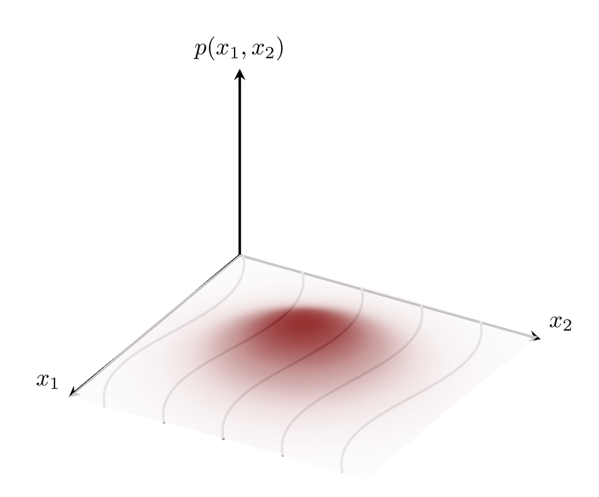

(a)

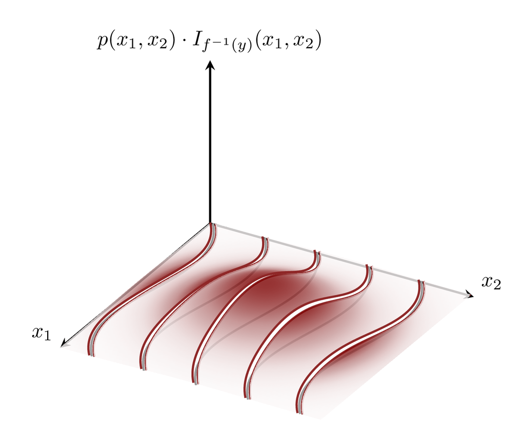

(b)

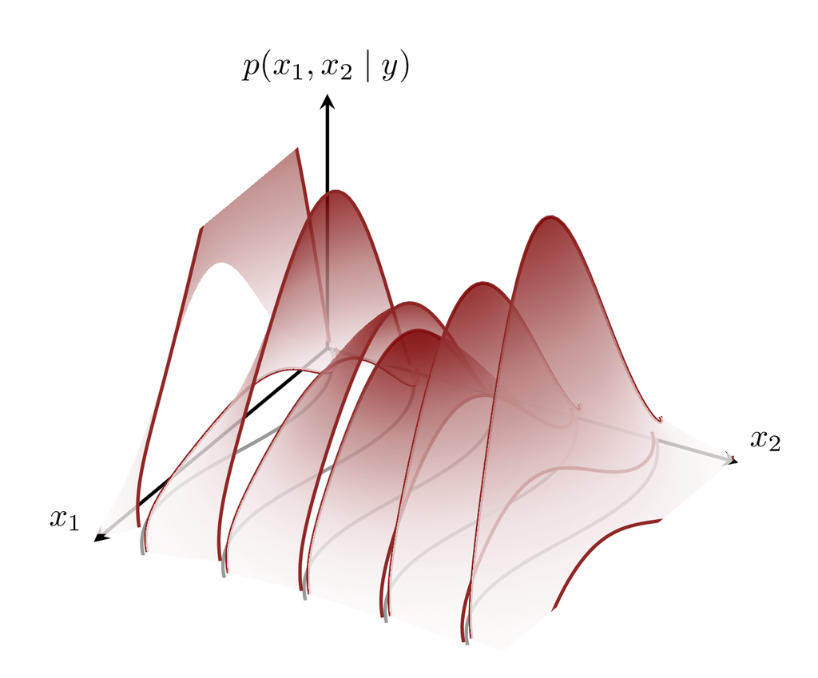

(c)

Figure 1: Conditional probability density functions are straightforward to construct for countable partitions. (a) A probability density function representing the initial probability distribution is first (b) sliced into density functions restricted to each level set. (c) Once properly normalized, these truncated density functions become conditional probability density functions that represent each conditional probability distribution.

To double check our construction, we need to verify that each conditional probability density function
$$p^{f}(x \mid y) = \frac{ \mathrm{d} \pi^{f} }{ \mathrm{d} \mu }( x \mid y )$$
completely concentrates on the corresponding level set. Indeed,
$$\begin{align*}
\pi^{f}_{y}( f^{-1}(y) )
&=
\pi^{f}( f^{-1}(y) \mid y)
\\
&=
\int \mu( \mathrm{d} x) \,
\frac{ \mathrm{d} \pi^{f} }{ \mathrm{d} \mu }( x \mid y ) \,
I_{f^{-1}(y)}(x)
\\
&=
\int \mu( \mathrm{d} x) \,
\frac{ \frac{ \mathrm{d} \pi }{ \mathrm{d} \mu }(x) \,
I_{f^{-1}(y)}(x) }{ \pi ( f^{-1}(y) ) }
\,
I_{f^{-1}(y)}(x)
\\
&=
\frac{1}{ \pi ( f^{-1}(y) ) }
\int \mu( \mathrm{d} x) \, \frac{ \mathrm{d} \pi }{ \mathrm{d} \mu }(x) \,
\left( I_{f^{-1}(y)}(x) \right)^{2}
\\
&=
\frac{1}{ \pi ( f^{-1}(y) ) }
\int \mu( \mathrm{d} x) \, \frac{ \mathrm{d} \pi }{ \mathrm{d} \mu }(x) \,
I_{f^{-1}(y)}(x)
\\
&=
\frac{1}{ \pi ( f^{-1}(y) ) }
\pi( f^{-1}(y) )
\\
&=
1.
\end{align*}$$

Equivalently, we can verify that each conditional probability density function integrates to zero outside of the corresponding level set. For any measurable subset $\mathsf{x} \in \mathcal{X}$ that is disjoint with a particular level set,
$$\mathsf{x} \cap f^{-1}(y) = \emptyset,$$
we have
$$\begin{align*}
\pi^{f}_{y}( \mathsf{x} )
&=
\pi^{f}( \mathsf{x} \mid y)
\\
&=
\int \mu( \mathrm{d} x) \,
\frac{ \mathrm{d} \pi^{f} }{ \mathrm{d} \mu }( x \mid y ) \,
I_{\mathsf{x}}(x)
\\
&=
\int \mu( \mathrm{d} x) \,
\frac{ \frac{ \mathrm{d} \pi }{ \mathrm{d} \mu }(x) \,
I_{f^{-1}(y)}(x) }{ \pi ( f^{-1}(y) ) }
\,
I_{\mathsf{x}}(x)
\\
&=
\frac{1}{ \pi ( f^{-1}(y) ) }
\int \mu( \mathrm{d} x) \, \frac{ \mathrm{d} \pi }{ \mathrm{d} \mu }(x) \,
I_{f^{-1}(y)}(x) \, I_{\mathsf{x}}(x)
\\
&=
\frac{1}{ \pi ( f^{-1}(y) ) }
\int \mu( \mathrm{d} x) \, \frac{ \mathrm{d} \pi }{ \mathrm{d} \mu }(x) \,
I_{\mathsf{x} \cap f^{-1}(y) }(x)
\\
&=
\frac{1}{ \pi ( f^{-1}(y) ) }
\int \mu( \mathrm{d} x) \, \frac{ \mathrm{d} \pi }{ \mathrm{d} \mu }(x) \,
I_{ \emptyset }(x)
\\
&=
\frac{1}{ \pi ( f^{-1}(y) ) } \cdot 0
\\
&=
0.
\end{align*}$$

In both calculations we used some of the indicator function properties derived in [Chapter 5, Appendix](http://www.symplectomorphic.com//assets/chapters_html/expectation_values.html#sec:app).

# 3 The Problem With Null Partitions

Unfortunately, this construction doesn’t carry over to functions with more general output spaces. In particular, the construction falls apart for output spaces that contain an uncountably-infinite number of points.

For example, if $Y$ is uncountable then at least some, if not all, of the level sets must be allocated vanishing probabilities,
$$\pi( f^{-1}(y) ) = 0.$$
When $\pi( f^{-1}(y) ) = 0$, the final definition of a discrete conditional probability density function
$$\frac{ \mathrm{d} \pi^{f} }{ \mathrm{d} \mu }( x \mid y )
\overset{ \mu }{ = }
\frac{
\frac{ \mathrm{d} \pi }{ \mathrm{d} \mu }(x) \, I_{f^{-1}(y)}(x)
}{
\pi ( f^{-1}(y) )
}$$
requires an ill-defined division by zero.

Unsurprisingly, problems arise earlier in the calculation itself. On the right-hand side of the law of total expectation, we cannot convert the output expectation value over $f_{*} \pi$ into a sum over individual output elements if $Y$ is uncountable. Similarly, when $Y$ is uncountable, we cannot apply the *countable* linearity of measure-informed integration to the completeness equation
$$1 = \sum_{y \in Y} I_{f^{-1}(y)}(x).$$

More fundamentally, any $\sigma$-finite reference measure will allocate vanishing measure to at least some, if not all, of the level sets,
$$\mu( f^{-1}(y) ) = 0.$$
If $\mu(f^{-1}(y)) = 0$ then any probability distribution that is absolutely continuous with respect to $\mu$ must also allocate zero probability to $f^{-1}(y)$. The conditional probability distributions $\pi^{f}_{y}$, however, allocate all of their probability to the corresponding level set $f^{-1}(y)$!

In other words, the conditional probability distributions over an uncountable partition are generally not absolutely continuous with respect to $\mu$. The lack of absolute continuity prevents us from converting conditional expectation values into $\mu$-informed integrals weighted by a conditional probability density function in the first place. Absolute continuity is easy to disregard as unnecessarily abstract, but every now and then it has important practical consequences!

Yet another way to see that we need a more general construction of conditional probability density functions is to assume that a probability density function of a particular $\pi^{f}_{y}$ with respect to $\mu$ does exist, and then show that a mathematical inconsistency arises.

For instance, in order to ensure that
$$\pi^{f}_{y}( f^{-1}(y) ) = \pi^{f}( f^{-1}(y) \mid y) = 1$$
we would need a conditional probability density function to satisfy
$$\begin{align*}
1
&=
\pi^{f}( f^{-1}(y) \mid y)
\\
&=
\int \pi^{f}( \mathrm{d} x \mid y) \, I_{f^{-1}(y)}(x)
\\
&=
\int \mu( \mathrm{d} x) \,
\frac{ \mathrm{d} \pi^{f} }{ \mathrm{d} \mu }(x \mid y) \, I_{f^{-1}(y)}(x).
\end{align*}$$
If, however, $\mu( f^{-1}(y) ) = 0$ then the indicator function will be non-zero for only a $\mu$-null subset of inputs.

Consequently, in terms of $\mu$-informed integrals this integrand should be equivalent to the zero function,
$$I_{f^{-1}(y)}(x) \overset{\mu}{=} 0.$$
This implies
$$\begin{align*}
\int \mu( \mathrm{d} x) \,
\frac{ \mathrm{d} \pi^{f} }{ \mathrm{d} \mu }(x \mid y) \, I_{f^{-1}(y)}(x)
&=
\int \mu( \mathrm{d} x) \,
\frac{ \mathrm{d} \pi^{f} }{ \mathrm{d} \mu }(x \mid y) \cdot 0
\\
&= 0,
\end{align*}$$
and then
$$1 = \int \mu( \mathrm{d} x) \,
\frac{ \mathrm{d} \pi^{f} }{ \mathrm{d} \mu }(x \mid y) \, I_{f^{-1}(y)}(x) = 0.$$
Unfortunately, $1 = 0$ a pretty immediate mathematical contradiction!

Notice the similarity between these problems and the awkward behavior that we encountered when exploring the Dirac delta function in [Chapter 6, Section 5.1](http://www.symplectomorphic.com/assets/chapters_html/density_functions.html). When $f^{-1}(y)$ is a $\mu$-null subset, the corresponding conditional probability distribution $\pi^{f}_{y}$ becomes singular relative to ambient reference measures. In this case, probability density functions become ill-defined without opening our hearts and minds to generalized functions like the Dirac delta function.

Ultimately, any general construction of conditional probability density functions requires reference measures that are sufficiently well-behaved within each level set, even if they appear singular relative to well-behaved ambient reference measures. These reference measures are often much easier to understand if we interpret conditional probability distributions $\pi^{f}_{y}$ as probability distributions over just the corresponding level set $f^{-1}(y)$.

If we can construct $\sigma$-finite reference measures over each level sets $\nu_{y}$, then we can define the conditional probability density functions
$$\int \pi^{f}( \mathrm{d} x \mid y ) \, g(x)
=
\int \nu_{y}( \mathrm{d} x ) \,
\frac{ \mathrm{d} \pi^{f} }{ \mathrm{d} \nu_{y} } (x \mid y) \, g(x).$$
Incorporating these probability functions into the law of total expectation, however, requires an explicit relationship between these level set reference measures $\nu_{y}$ and the ambient reference measure $\mu$. This, in turn, requires extending the disintegration of probability measures to the disintegration of more general measures.

# 4 Disintegrating Measures

In [Chapter 8, Section 3.2](http://www.symplectomorphic.com/assets/chapters_html/conditional_probability_theory.html#sec:general-conditional), we introduced disintegrations of probability distributions. This definition pretty immediately generalizes to *finite* measures, but it becomes problematic when working with non-finite measures. Decomposing even $\sigma$-finite measures across null subsets is non-trivial.

## 4.1 General Disintegrations

The core mathematical issue here is that a consistent disintegration of a measure $\mu$ with respect to a function $f : X \rightarrow Y$ requires not only that the initial measure $\mu$ is $\sigma$-finite, but also that its pushforward $f_{*} \mu$ is $\sigma$-finite. Unfortunately, this latter condition fails for most common reference measures.

Consider, for example, a rigid two-dimensional real space $\mathbb{R}^{2}$ equipped with the two-dimensional Lebesgue measure $\lambda^{2}$ and a projection function
$$\begin{alignat*}{6}
\varpi_{1} :\; &\mathbb{R}^{2}& &\rightarrow& \; &\mathbb{R}&
\\
&(x_{1}, x_{2})& &\mapsto& &x_{1}&.
\end{alignat*}$$
The Lebesgue measure $\lambda^{2}$ is $\sigma$-finite, allocating finite measure to every measurable subset that can be encapsulated in a finite rectangle. Formally, if
$$\mathsf{x} \subset [0, 1] \times [0, 1]$$
then
$$\begin{align*}
\lambda^{2}(\mathsf{x})
&<
\lambda^{2}( [0, 1] \times [0, 1] )
\\
&<
l([0, 1]) \cdot l([0, 1])
\\
&<
1 \cdot 1
\\
&<
1.
\end{align*}$$

Pushing $\lambda^{2}$ forward along $\varpi_{1}$, however, results in a measure that allocates *infinite* measure to finite intervals. For instance, (Figure 2),
$$\begin{align*}
(\varpi_{1})_{*} \lambda^{2} ( [0, 1] )
&=
\lambda^{2}( \varpi_{1}^{*} [0, 1])
\\
&= \lambda^{2}( [0, 1] \times (-\infty, \infty) )
\\
&= l([0, 1]) \cdot l( (-\infty, \infty) )
\\
&= 1 \cdot \infty
\\
&= \infty.
\end{align*}$$
Consequently $(\varpi_{1})_{*} \lambda^{2}$ cannot be $\sigma$-finite.

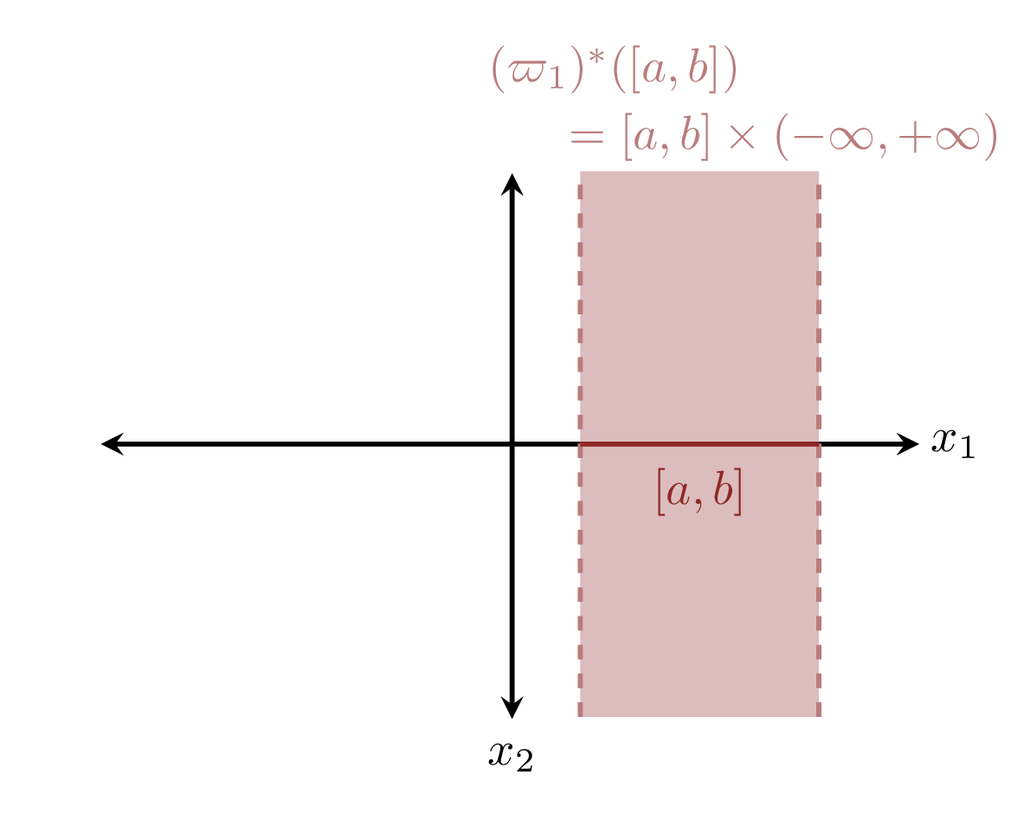

Figure 2: On $\mathbb{R}^{2}$, the projection function $\phi_{1} : (x_{1}, x_{2}) \mapsto x_{1}$ pulls finite output space intervals $[a, b]$ back to infinite input space rectangles $[a, b] \times (-\infty, +\infty)$. Consequently, the two dimensional Lebesgue measure $\lambda^{2}$ projects infinite measure onto finite intervals, and the pushforward measure $(\phi_{1})_{*} \lambda^{2}$ cannot be $\sigma$-finite. In particular, $\lambda^{2}$ does *not* pushforward to a Lebesgue measure on the output space!

Fortunately, disintegrations can be generalized to work with *any* convenient $\sigma$-finite measure on the output space. Mathematically, if we have

1. an input measurable space $(X, \mathcal{X})$,
2. an input $\sigma$-finite, Radon measure $\mu : \mathcal{X} \rightarrow [0, \infty]$,
3. an output Hausdorff measurable space $(Y, \mathcal{Y})$.
4. a surjective measurable function $f: (X, \mathcal{X}) \rightarrow (Y, \mathcal{Y})$,
5. and finally an output $\sigma$-finite measure $\nu : \mathcal{Y} \rightarrow [0, \infty]$,

then there exists at least one **conditional measure kernel**
$$\begin{alignat*}{6}
\mu^{f, \nu} :\; &\mathcal{X} \times Y& &\rightarrow& \; &[0, \infty]&
\\
&\mathsf{x}, y& &\mapsto& &\mu^{f}( \mathsf{x} \mid y )&
\end{alignat*}$$
that defines a $(\mathcal{Y}, \mathcal{B}_{\mathbb{R}})$-measurable function when partially evaluated on any $\mathsf{x} \in \mathcal{X}$ in the first argument,
$$\begin{alignat*}{6}
\mu^{f, \nu}_{\mathsf{x}} :\; &Y& &\rightarrow& \; &[0, \infty]&
\\
&y& &\mapsto& &\mu^{f, \nu}( \mathsf{x} \mid y )&,
\end{alignat*}$$
and a $\sigma$-finite measure when partially evaluated on $\nu$-almost any $y \in Y$ in the second argument,
$$\begin{alignat*}{6}
\mu^{f}_{y, \nu} :\; &\mathcal{X}& &\rightarrow& \; &[0, \infty]&
\\
&\mathsf{x}& &\mapsto& &\mu^{f, \nu}( \mathsf{x} \mid y )&.
\end{alignat*}$$
A more technical discussion can be found in Chang and Pollard (1997).

The conditional measures derived from a conditional measure kernel behave very similarly to conditional probability distributions. For instance, they each concentrate on a particular level set,
$$\mu^{f, \nu}_{y}( f^{-1}(x) ) \overset{\nu}{=} 1$$
with
$$\mu^{f, \nu}_{y}( \mathsf{x} ) \overset{\nu}{=} 0$$
for any disjoint subset $\mathsf{x} \cap f^{-1}(y) = \emptyset$. Because of this concentration, if
$$\mu( \, f^{-1}(y) \, ) = 0$$
then the conditional measure $\mu^{f, \nu}_{y}$ will *not* be absolutely continuous with respect to the initial measure!

For any well-behaved integrand $g : X \rightarrow \mathbb{R}$, the conditional measures also satisfy a law of total integration,
$$\int \mu( \mathrm{d} x ) \, g(x)
=
\int \nu (\mathrm{d} y)
\int \mu^{f, \nu}( \mathrm{d}x_{y} \mid y ) \,
g( \iota_{y}(x_{y})).$$

In circumstances where $f_{*} \mu$ happens to be $\sigma$-finite, we can always take $\nu = f_{*} \mu$ so that the law of total integration mirrors the law of total expectation. This is always possible if $\mu$ is a finite measure, and hence always possible when disintegrating probability distributions. It is not, however, always viable when $\mu$ is only $\sigma$-finite. In particular, we have to be vigilant when attempting to disintegrate Lebesgue measures, as they often pushforward to measures that are not $\sigma$-finite.

## 4.2 Lebesgue Disintegrations

In theory, the disintegration of an input space measure with respect to an output space measure defines reference measures adapted to each level set of a surjective function $f: X \rightarrow Y$. This construction isn’t all that useful, however, if we cannot explicitly integrate against these conditional reference measures. Fortunately, the integration of conditional Lebesgue measures reduces to standard operations from multivariate calculus.

Consider an $N$-dimensional space $X = \mathbb{R}^{N}$ equipped with a Lebesgue measure $\mu = \lambda^{N}$ and an $M$-dimensional space $Y = \mathbb{R}^{M}$ equipped with a Lebesgue measure $\nu = \lambda^{M}$. Moreover, assume that $N > M$.

In this case, any smooth, surjective function $f: \mathbb{R}^{N} \rightarrow \mathbb{R}^{M}$ defines level sets that are $\lambda^{Y}$ almost all $(N - M)$-dimensional. These level sets not only partition $X$ but also disintegrate $\mu$ into conditional Lebesgue measures that concentrate within each of these level sets.

If $M = N - 1$ then almost all of the level sets will be one-dimensional. We can always completely cover the one-dimensional level set with a countable number of one-dimensional curves through $X$; usually one curve is sufficient, but we have to be careful in case, for example, the level sets are disconnected. Moreover, the conditional integral of any function $g : X \rightarrow \mathbb{R}$ with respect to $\mu^{f, \nu}$ is given but summing up the **line integrals** Larson, Hostetler, and Edwards (1990) of $g$ over each of these curves.

More explicitly, let’s say that the level set $f^{-1}(y)$ can be completely traced out by the single curve
$$\gamma_{y} : [a, b] \rightarrow X,$$
with the real-valued variable
$$z \in [a, b] \subset \mathbb{R}$$
tracking the relative position along the curve. In this case, the conditional integral of $g$ with respect to $\mu^{f, \lambda^{X}}$ can be evaluated as
$$\begin{align*}
i_{y}
&=
\int \mu^{f, \nu}( \mathrm{d}x_{y} \mid y ) \,
g(\iota_{y}(x_{y}))
\\
&=
\int_{a}^{b} \mathrm{d} z \, J_{y}(z) \, g( \gamma_{y}(z) ),
\end{align*}$$
where $J_{y}(z)$ is the Jacobian correction,
$$J_{y}(z)
=
\sqrt{
\sum_{n = 1}^{N}
\left(
\frac{ \mathrm{d} \gamma_{y, n} }{ \mathrm{d} z } (z)
\right)^{2}
}.$$

Similarly, if $M = N - 2$ then almost level sets of any smooth, surjective function $f: \mathbb{R}^{N} \rightarrow \mathbb{R}^{M}$ will be two-dimensional. These two-dimensional level sets can be covered by a two-dimensional surfaces, with conditional measures given by **surface integrals** over those surfaces.

To anchor all of this abstraction, let’s consider an explicit example using the two-dimensional space $X = \mathbb{R}^{2}$ and the radial function
$$\begin{alignat*}{6}
f :\; &X& &\rightarrow& \; &\mathbb{R}^{+}&
\\
&(x_{1}, x_{2})& &\mapsto& &r = \sqrt{ x_{1}^{2} + x_{2}^{2} }&.
\end{alignat*}$$

All of the level sets of this function are concentric circles, except for $f^{-1}(0)$ which reduces to a singular point. Each of the non-singular level sets can be traced out by a circular curve (Figure 3). Here we’ll use the curves
$$\begin{alignat*}{6}
\gamma_{r} :\; &[0, 2 \, \pi )& &\rightarrow& \; &\mathbb{R}^{2}&
\\
&\theta& &\mapsto& &( r \, \cos \theta, r \, \sin \theta )&.
\end{alignat*}$$

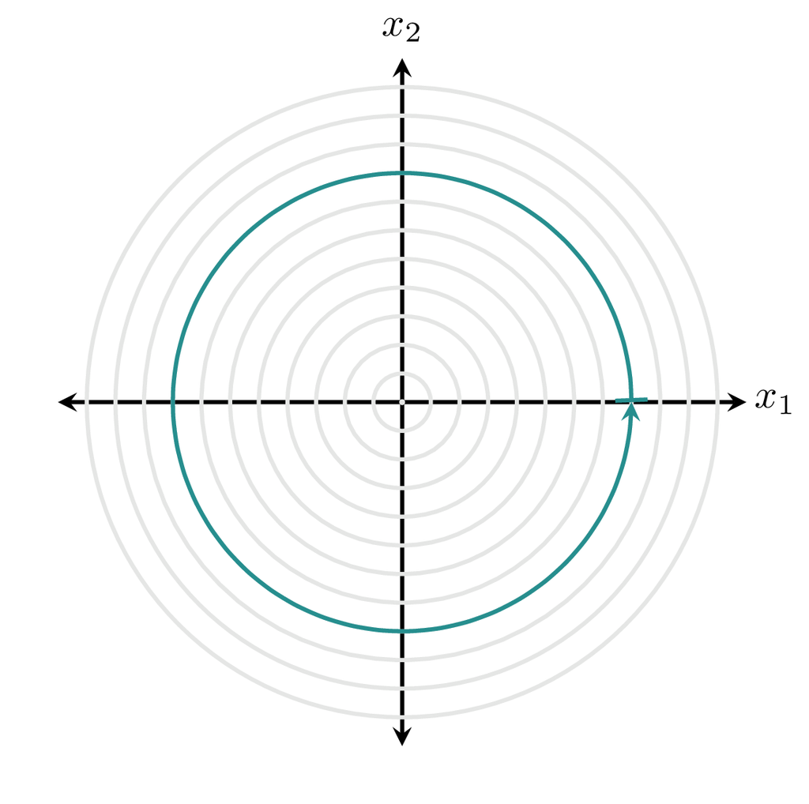

Figure 3: The circular level sets of the radial function $f: (x_{1}, x_{2}) \mapsto r = \sqrt{ x_{1}^{2} + x_{2}^{2} }$ partition the input space $\mathbb{R}^{2}$. All but the singular level set $f^{-1}(0)$ can be parameterized by one-dimensional curves, an example of which is shown here in teal. Integrals with respect to conditional Lebesgue measures can be evaluated as line integrals over these curves.

Given the Jacobian correction
$$\begin{align*}
J_{r}
&=
\sqrt{
\left(
\frac{
\mathrm{d} \gamma_{r, 1}
}{
\mathrm{d} \theta
} ( \theta )
\right)^{2}
+
\left(
\frac{
\mathrm{d} \gamma_{r, 2}
}{
\mathrm{d} \theta
} ( \theta )
\right)^{2}
}
\\
&=
\sqrt{
\left(
\frac{
\mathrm{d} r \, \cos \theta
}{
\mathrm{d} \theta
}
\right)^{2}
+
\left(
\frac{
\mathrm{d} r \, \sin \theta
}{
\mathrm{d} \theta
}
\right)^{2}
}
\\
&=
\sqrt{
\left(
r \, \sin \theta
\right)^{2}
+
\left(
- r \, \cos \theta
\right)^{2}
}
\\
&=
\sqrt{
r^{2} \,
\left(
\sin^{2} \theta + \cos^{2} \theta
\right)^{2}
}
\\
&=
\sqrt{
r^{2}
}
\\
&=
r,
\end{align*}$$
the conditional integral over one of these curves is given by
$$\begin{align*}
i_{r}
&=
\int \mu^{f, \nu}( \mathrm{d} x_{r} \mid r ) \,
g(\iota_{r}(x_{r}))
\\
&=
\int_{0}^{2 \, \pi} \mathrm{d} \theta \,
J_{r}(\theta) \, g( \gamma_{r}(\theta) )
\\
&=
\int_{0}^{2 \, \pi} \mathrm{d} \theta \,
r \, g( r \, \cos \theta, r \, \sin \theta ).
\end{align*}$$

# 5 Conditional Probability Density Functions For General Implicit Partitions

Armed with a technique for disintegrating $\sigma$-finite measures, we are now finally equipped with enough tools to construct conditional probability density functions for any conditional probability distribution paired with a sufficiently well-behaved reference measure.

## 5.1 Setup

Recall that to construct a conditional probability distribution we need

1. an input measurable space $(X, \mathcal{X})$,
2. an input Radon probability distribution $\pi : \mathcal{X} \rightarrow [0, 1]$,
3. an output Hausdorff measurable space $(Y, \mathcal{Y})$.
4. and a surjective measurable function $f: (X, \mathcal{X}) \rightarrow (Y, \mathcal{Y})$.

In order to construct conditional probability density functions, we will also need convenient $\sigma$-finite Radon reference measures for

5. the input space, $\mu : \mathcal{X} \rightarrow [0, \infty]$
6. and the output space, $\nu : \mathcal{Y} \rightarrow [0, \infty]$.

Disintegrating the input space reference measure with respect to $f$ and the output space reference measure gives $\sigma$-finite reference measures over each level set,

7. $\mu^{f, \nu} : \mathcal{F}_{y} \rightarrow [0, \infty]$.

As we have previously discussed, we can safely take measurable functions, Hausdorff $\sigma$-algebras, and Radon measures for granted in practice. We will, however, have to be careful about the surjectivity of $f$ and the $\sigma$-finiteness of the reference measures.

If $\pi \ll \mu$, then we can construct the probability density function
$$\frac{ \mathrm{d} \pi }{ \mathrm{d} \mu } : X \rightarrow \mathbb{R}^{+},$$
and if $f_{*} \pi \ll \nu$ then we can construct the pushforward probability density function
$$\frac{ \mathrm{d} f_{*} \pi }{ \mathrm{d} \nu } : Y \rightarrow \mathbb{R}^{+}.$$
Upon disintegrating $\mu$, we can construct conditional probability density functions relative to the conditional measures,
$$\frac{ \mathrm{d} \pi^{f} }{ \mathrm{d} \mu^{f, \nu} }
: X \times Y \rightarrow \mathbb{R}^{+}.$$

## 5.2 The Product Rule

All that we’re missing is a mathematical relationship that ties all of these different probability density functions together. That is hidden within the law of total expectation,
$$\begin{align*}
\int \pi( \mathrm{d} x ) \, g(x)
&=
\int f_{*} \pi (\mathrm{d} y)
\int \pi^{f}( \mathrm{d}x_y \mid y ) \, g( \iota_{y}(x_{y}) )
\\
L
&=
R.
\end{align*}$$
All we need to do is convert both sides of this equation into the same kind of measure-informed integral.

Let’s start with the left-hand side,
$$\begin{align*}
L
&=
\int \pi ( \mathrm{d} x ) \, g(x)
\\
&=
\int \mu ( \mathrm{d} x ) \, \frac{ \mathrm{d} \pi}{ \mathrm{d} \mu }(x) \, g(x).
\end{align*}$$
Disintegrating $\mu$ with respect to $f$ and $\nu$ allow us to write this as
$$\begin{align*}
L
&=
\int \mu ( \mathrm{d} x ) \, \frac{ \mathrm{d} \pi}{ \mathrm{d} \mu }(x) \, g(x)
\\
&=
\int \nu ( \mathrm{d} y ) \,
\int \mu^{f, \nu}( \mathrm{d} x_{y} \mid y) \,
\frac{ \mathrm{d} \pi}{ \mathrm{d} \mu }( \iota_{y}(x_{y}) ) \, g( \iota_{y}(x_{y}) ).
\end{align*}$$

Over on the right-hand side, we have
$$\begin{align*}
R
&=
\int f_{*} \pi (\mathrm{d} y)
\int \pi^{f}( \mathrm{d}x_{y} \mid y ) \,
g( \iota_{y}(x_{y}) )
\\
&=
\int \nu (\mathrm{d} y) \,
\frac{ \mathrm{d} f_{*} \pi }{ \mathrm{d} \nu }(y) \,
\int \pi^{f}( \mathrm{d}x_{y} \mid y ) \,
g( \iota_{y}(x_{y}) )
\\
&=
\int \nu (\mathrm{d} y) \,
\frac{ \mathrm{d} f_{*} \pi }{ \mathrm{d} \nu }(y) \,
\int \mu^{f, \nu} ( \mathrm{d}x_{y} \mid y ) \,
\frac{ \mathrm{d} \pi^{f} }{ \mathrm{d} \mu^{f, \nu} }(x_{y} \mid y) \,
g( \iota_{y}(x_{y}) ).
\end{align*}$$

Because the domain of the inner measure-informed integral is single level set, the pushforward probability density function
$$\frac{ \mathrm{d} f_{*} \pi }{ \mathrm{d} \nu }(y)$$
is constant. Consequently, we can pull it inside the inner integral to give
$$\begin{align*}
R
&=
\int \nu (\mathrm{d} y) \,
\frac{ \mathrm{d} f_{*} \pi }{ \mathrm{d} \nu }(y) \,
\int \mu^{f, \nu} ( \mathrm{d}x_{y} \mid y ) \,
\frac{ \mathrm{d} \pi^{f} }{ \mathrm{d} \mu^{f, \nu} }(x_{y} \mid y) \,
g( \iota_{y}(x_{y}) )
\\
&=
\int \nu (\mathrm{d} y) \,
\int \mu^{f, \nu} ( \mathrm{d}x_{y} \mid y ) \,
\left[
\frac{ \mathrm{d} f_{*} \pi }{ \mathrm{d} \nu }(y) \,
\frac{ \mathrm{d} \pi^{f} }{ \mathrm{d} \mu^{f, \nu} }(x_{y} \mid y)
\right] \,
g( \iota_{y}(x_{y}) ).
\end{align*}$$

At this point, we can put these two pieces back together,
$$\begin{align*}
&
\quad\; L = R
\\
&
\int \pi( \mathrm{d} x ) \, g(x)
\\
&\quad\quad=
\int f_{*} \pi (\mathrm{d} y)
\int \pi^{f}( \mathrm{d}x_{y} \mid y ) \, g( \iota_{y}(x_{y}) )
\\
&
\int \nu ( \mathrm{d} y ) \,
\int \mu^{f, \nu}( \mathrm{d} x_{y} \mid y) \,
\frac{ \mathrm{d} \pi}{ \mathrm{d} \mu }( \iota_{y}(x_{y}) ) \, g( \iota_{y}(x_{y}) )
\\
&\quad\quad=
\int \nu (\mathrm{d} y) \,
\int \mu^{f, \nu} ( \mathrm{d}x_{y} \mid y ) \,
\left[
\frac{ \mathrm{d} f_{*} \pi }{ \mathrm{d} \nu }(y) \,
\frac{ \mathrm{d} \pi^{f} }{ \mathrm{d} \mu^{f, \nu} }(x_{y} \mid y)
\right] \,
g( \iota_{y}(x_{y}) ).
\end{align*}$$

Because both sides of the equation are the same kind of measure-informed integral, we have equality if and only if the integrands on both sides are equal up to null subsets. In particular, we have equality for all integrands $g : X \rightarrow \mathbb{R}$ if and only if
$$\frac{ \mathrm{d} \pi}{ \mathrm{d} \mu }( \iota_{y}(x_{y}) )
\overset{ \nu, \mu^{f, \nu} }{ = }
\frac{ \mathrm{d} f_{*} \pi }{ \mathrm{d} \nu }(y) \,
\frac{ \mathrm{d} \pi^{f} }{ \mathrm{d} \mu^{f, \nu} }(x_{y} \mid y).$$

This relationship is known as the **product rule** for probability density functions. The product rule allows to construct the ambient probability density function, the conditional probability density function, or the pushforward probability density function given the other two. For instance, if we know the ambient probability density function and the pushforward probability density function, then the conditional probability density function is given by
$$\frac{ \mathrm{d} \pi^{f} }{ \mathrm{d} \mu^{f, \nu} } (x_{y} \mid y)
\overset{ \nu, \mu^{f, \nu} }{ = }
\frac{
\frac{ \mathrm{d} \pi}{ \mathrm{d} \mu }( \iota_{y}(x_{y}) )
}{
\frac{ \mathrm{d} f_{*} \pi }{ \mathrm{d} \nu }(y)
}.$$

Phew. Let’s take a breath and summarize how far we’ve come!

We can condition an arbitrary probability density function
$$p(x) = \frac{ \mathrm{d} \pi}{ \mathrm{d} \mu }( x )$$
on the output point $y \in Y$ in two steps. First, we restrict the inputs to the points in the level set $f^{-1}(y)$ (Figure 4 (b)}),
$$p( \iota_{y}(x_{y}) ).$$
Next, we divide by the pushforward probability density function evaluated at $y$,
$$p(y) = \frac{ \mathrm{d} f_{*} \pi }{ \mathrm{d} \nu }(y),$$
to give (Figure 4 (c)),
$$p( x_{y} \mid y )
=
\frac{
p( \iota_{y}(x_{y}) )
}{
p(y)
}.$$

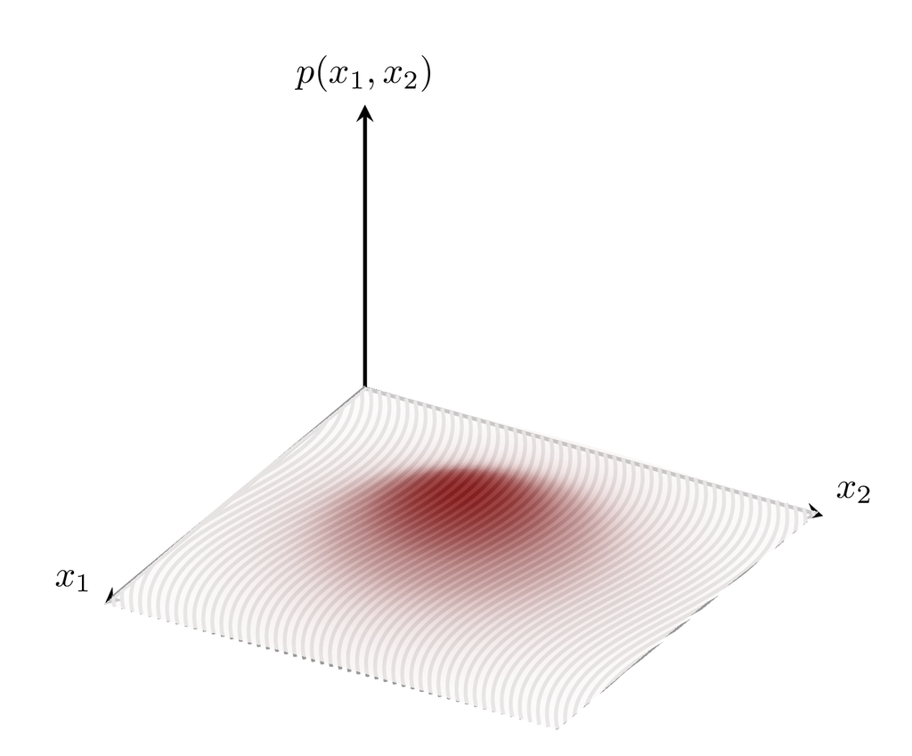

(a)

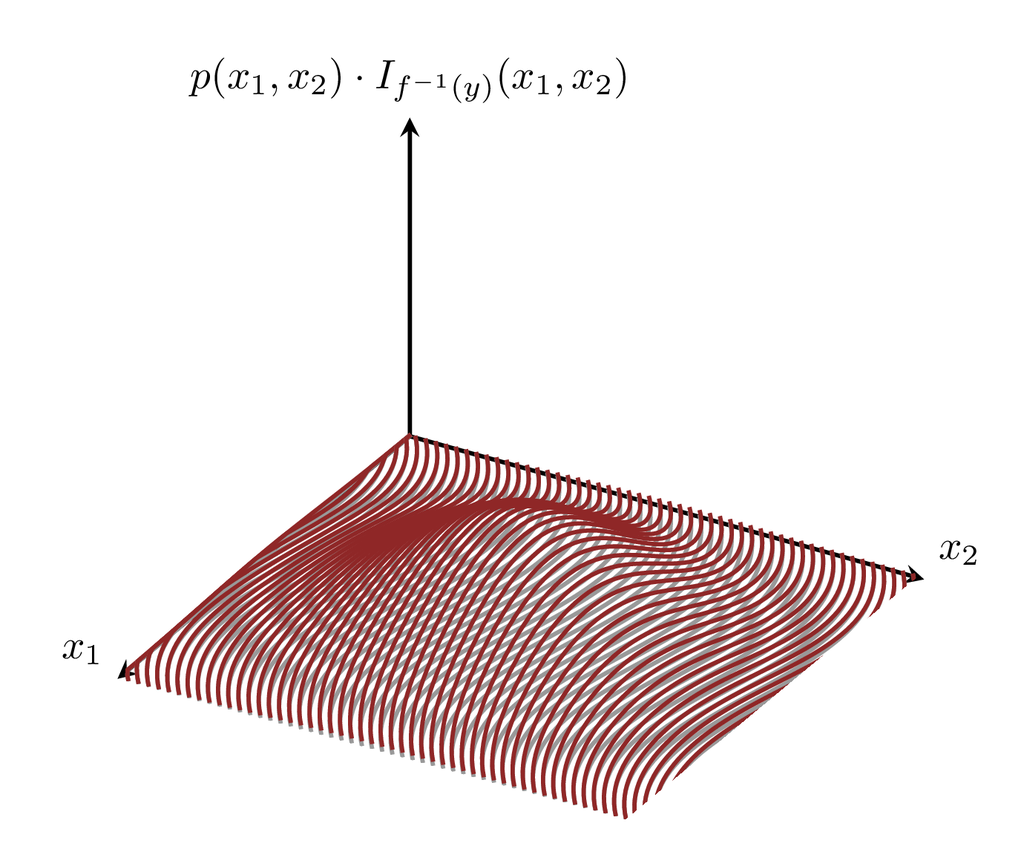

(b)

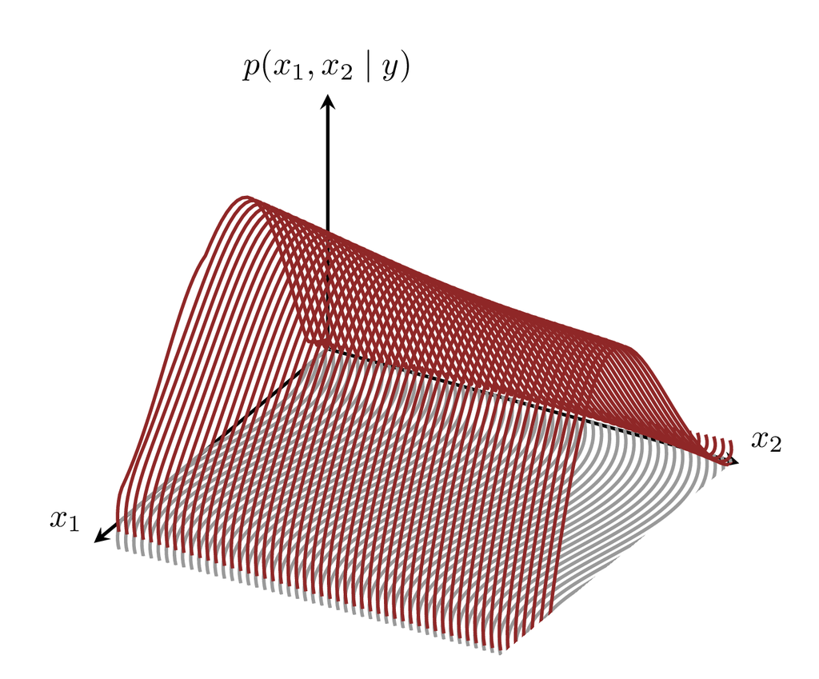

(c)

Figure 4: The product rule allows us to generalize the construction of conditional probability density functions that we first encountered in Section 2 to any measurable partitions. (a) An initial probability density function is first (b) sliced into a collection of conditional density functions by restricting valid inputs to a particular level set. (c) Dividing by the corresponding pushforward probability density normalizes these restricted density functions into conditional probability density functions.

Notice that the normalization step doesn’t change the *shape* of a conditional probability density function for a given $y$, just its height relative to other possible values of $y$. In applications where we’re interested in only a single $y$, we can usually ignore this last step, and any difficulty in evaluating the pushforward probability density function, entirely.

## 5.3 Example

To demonstrate this process, consider a surjective function $f : X \rightarrow \mathbb{N}$ that maps input points to output integers. Because the output space is discrete, this function induces a countable partition of the input space. Moreover, a counting measure is a natural output reference measure, $\nu = \chi$.

If $f_{*} \mu( \{ y \} ) > 0$ for all $y \in \mathbb{N}$, then each $\mu^{f, \chi}_{y}$ is just $\mu$ truncated to a particular level set,
$$\mu^{f, \chi}_{y} = \eta_{y} = I_{f^{-1}(y)} \cdot \mu.$$

In this case, the product rule gives
$$\begin{align*}
\frac{ \mathrm{d} \pi^{f} }{ \mathrm{d} \mu^{f, \chi} } (x_{y} \mid y)
&\overset{ \mu }{ = }
\frac{
\frac{ \mathrm{d} \pi}{ \mathrm{d} \mu }( \iota_{y}(x_{y}) )
}{
\frac{ \mathrm{d} f_{*} \pi }{ \mathrm{d} \chi }(y)
}
\\
&\overset{ \mu }{ = }
\frac{
\frac{ \mathrm{d} \pi}{ \mathrm{d} \mu }( \iota_{y}(x_{y}) )
}{
f_{*} \pi ( \{ y \} )
}
\\
&\overset{ \mu }{ = }
\frac{
\frac{ \mathrm{d} \pi}{ \mathrm{d} \mu }( \iota_{y}(x_{y}) )
}{
\pi ( f^{-1}(y) )
}.
\end{align*}$$

For a given $y \in Y$, we can extend these conditional density functions to all inputs $x \in X$ by returning zero outside of the corresponding level set,
$$\frac{ \mathrm{d} \pi^{f} }{ \mathrm{d} \mu^{f, \chi} } (x \mid y)
\overset{ \mu }{ = }
\left\{
\begin{array}{rr}
\frac{ \frac{ \mathrm{d} \pi}{ \mathrm{d} \mu }(x) }{ \pi ( f^{-1}(y) ) },
& x \in f^{-1}(y)
\\
0,
& x \notin f^{-1}(y)
\end{array}
\right. ,$$
or, more compactly,
$$\frac{ \mathrm{d} \pi^{f} }{ \mathrm{d} \mu^{f, \chi} } (x \mid y)
\overset{ \mu }{ = }
\frac{
\frac{ \mathrm{d} \pi}{ \mathrm{d} \mu }(x) \, I_{f^{-1}(y)}(x)
}{
\pi ( f^{-1}(y) )
}.$$

This general result is consistent with the particular result that we derived in Section 2. In other words, using the general product rule will always give us a well-defined conditional probability density function.

# 6 Explicit Formula For Pushforward Probability Density Functions

The disintegration of reference measures is also how we can derive an explicit formula for pushforward probability density functions.

Recall the definition of pullback expectation values: for sufficiently-measurable functions $f : X \rightarrow Y$ and $h : Y \rightarrow \mathbb{R}$, we have
$$\begin{align*}
\mathbb{E}_{\pi} \! \left[ h \circ f \right]
&=
\mathbb{E}_{f_{*} \pi} \! \left[ h \right]
\\
\mathbb{I}_{\mu} \! \left[ \frac{ \mathrm{d} \pi }{ \mathrm{d} \mu } \, h \circ f \right]
&=
\mathbb{I}_{\nu} \! \left[ \frac{ \mathrm{d} f_{*} \pi }{ \mathrm{d} \nu } \, h \right],
\end{align*}$$
or, equivalently,
$$\begin{align*}
\int \pi( \mathrm{d} x ) \, h(f(x))
&=
\int f_{*} \pi( \mathrm{d} y ) \, h(y)
\\
\int \mu( \mathrm{d} x ) \, \frac{ \mathrm{d} \pi }{ \mathrm{d} \mu }(x) \, h(f(x))
&=
\int \nu( \mathrm{d} y ) \, \frac{ \mathrm{d} f_{*} \pi }{ \mathrm{d} \nu }(y) \, h(y).
\end{align*}$$

Disintegrating $\mu$ with respect to $f$ and $\nu$ allows us to write the left-hand side as
$$\begin{align*}
\int \pi( \mathrm{d} x ) \, h(f(x))
&=
\int \mu( \mathrm{d} x ) \, \frac{ \mathrm{d} \pi}{ \mathrm{d} \mu }(x) \, h(f(x))
\\
&=
\int \nu( \mathrm{d} y ) \,
\int \mu^{f, \nu}( \mathrm{d} x_{y} \mid y ) \,
\frac{ \mathrm{d} \pi}{ \mathrm{d} \mu }( \iota_{y}(x_{y}) ) \, h(y).
\end{align*}$$

Because the function $h \circ f : X \rightarrow \mathbb{R}$ yields the same output for any $x \in f^{-1}(y)$, it is a constant with respect to the inner integral. Consequently, we can factor it out,
$$\begin{align*}
\int \pi( \mathrm{d} x ) \, h(f(x))
&=
\int \nu( \mathrm{d} y ) \,
\int \mu^{f, \nu}( \mathrm{d} x_{y} \mid y ) \,
\frac{ \mathrm{d} \pi}{ \mathrm{d} \mu }( \iota_{y}(x_{y}) ) \, h(y)
\\
&=
\int \nu( \mathrm{d} y )
\left[
\int \mu^{f, \nu}( \mathrm{d} x_{y} \mid y ) \,
\frac{ \mathrm{d} \pi}{ \mathrm{d} \mu }( \iota_{y}(x_{y}) )
\right] \, h(y).
\end{align*}$$

Our initial equation then becomes
$$\begin{align*}
\int \pi( \mathrm{d} x ) \, h(f(x))
&=
\int f_{*} \pi( \mathrm{d} y ) \, h(y)
\\
\int \nu( \mathrm{d} y )
\left[
\int \mu^{f, \nu}( \mathrm{d} x_{y} \mid y ) \,
\frac{ \mathrm{d} \pi}{ \mathrm{d} \mu }( \iota_{y}(x_{y}) )
\right] \, h(y)
&=
\int \nu( \mathrm{d} y ) \,
\left[ \frac{ \mathrm{d} f_{*}\pi}{ \mathrm{d} \nu }(y) \right] \, h(y).
\end{align*}$$

Because both sides of this equation are $\nu$-informed integrals, we have equality if and only if the integrands are equal up to $\nu$-null subsets. In particular, we have equality for any integrand $h : Y \rightarrow \mathbb{R}$ if and only if
$$\frac{ \mathrm{d} f_{*}\pi}{ \mathrm{d} \nu }(y)
\overset{\nu}{=}
\int \mu^{f, \nu}( \mathrm{d} x_{y} \mid y ) \,
\frac{ \mathrm{d} \pi}{ \mathrm{d} \mu }( \iota_{y}(x_{y}) ).$$

In theory, this gives us an explicit formula for deriving pushforward probability density functions. Implementing this result in practice, however, requires an explicit method for evaluating conditional integrals over each level set of $f$. Fortunately, we know how to do this when working with real spaces and Lebesgue measures.

Consider, for example, the two-dimensional positive real space $X = \mathbb{R}^{+} \times \mathbb{R}^{+}$ equipped with a Lebesgue measure $\mu = \lambda^{2}$, a Lebesgue probability density function
$$p(x_{1}, x_{2}) = \frac{ \mathrm{d} \pi}{ \mathrm{d} \mu }(x_{1}, x_{2}),$$
and the radial function
$$\begin{alignat*}{6}
f :\; &X& &\rightarrow& \; &\mathbb{R}^{+}&
\\
&(x_{1}, x_{2})& &\mapsto& &r = \sqrt{ x_{1}^{2} + x_{2}^{2} }&.
\end{alignat*}$$

Because $X$ is restricted to non-negative values, the level sets of $f$ define not entire circles but rather circular arcs (Figure 5). We’ll cover these arcs with the curves
$$\begin{alignat*}{6}
\gamma_{r} :\; &[0, \pi / 2 )& &\rightarrow& \; &X&
\\
&\theta& &\mapsto& &( r \, \cos \theta, r \, \sin \theta )&.
\end{alignat*}$$

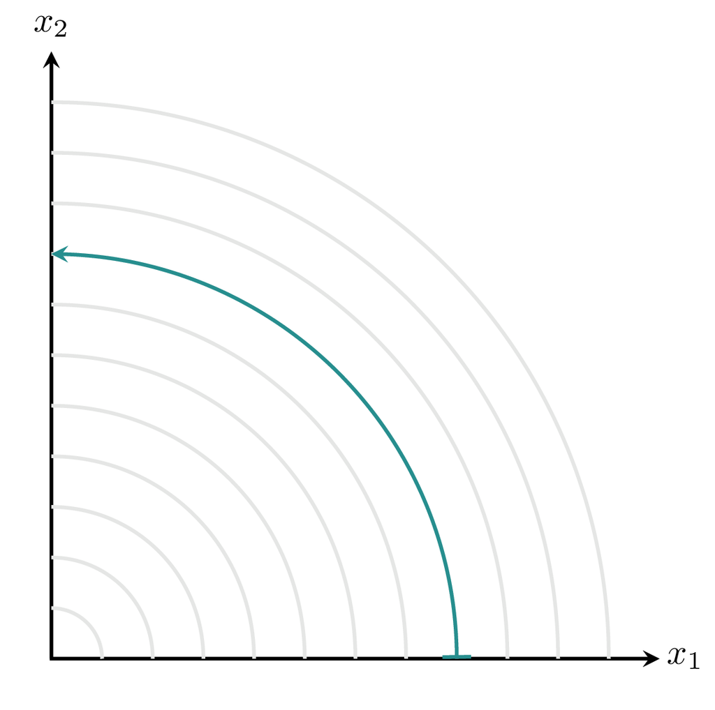

Figure 5: When the inputs are restricted to non-negative values, the level sets of the radial function $f: (x_{1}, x_{2}) \mapsto r = \sqrt{ x_{1}^{2} + x_{2}^{2} }$ partition the input space into circular arcs, each of which can be parameterized with a curve of constant radius, one of which an is shown here in teal. Integrals with respect to conditional Lebesgue measures can be evaluated as line integrals over these curves.

In this case, the Jacobian correction is the same as it was for the example of Section 4.2,
$$J_{r} = r.$$
Consequently, we write the pushforward probability density function as (Figure 6 (b))
$$\begin{align*}
p(r)
&=
\int_{0}^{ \frac{\pi}{2} } \mathrm{d} \theta \,
J_{r}(\theta) \, p( \gamma_{r}(\theta) )
\\
&=
\int_{0}^{ \frac{\pi}{2} } \mathrm{d} \theta \,
r \, p( r \, \cos \theta, r \, \sin \theta ).
\end{align*}$$
At this point, we can use the product rule to construct the conditional probability density function over each level set (Figure 6 (c)),
$$p(\theta_{r} \mid r) = \frac{ p(r, \theta_{r}) }{ p(r) }.$$

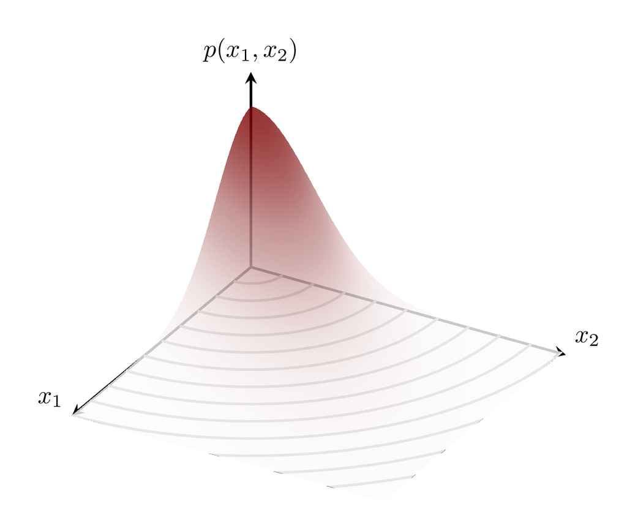

(a)

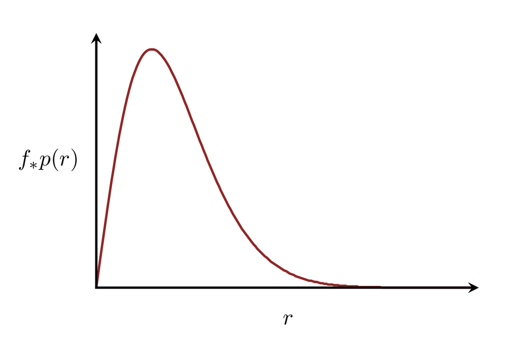

(b)

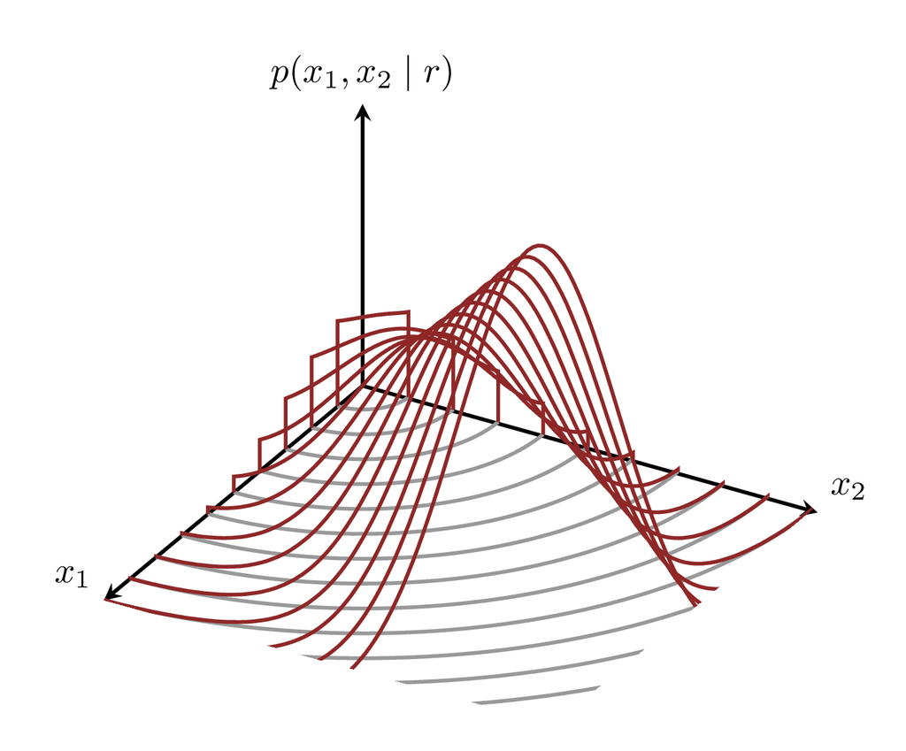

(c)

Figure 6: When we have the computational tools to evaluate conditional integrals over level sets, we can evaluate pushforward probability density functions. Here we integrate (a) an initial density function over circular level sets to derive (b) a pushforward probability density function over output radii. (c) Restricting the initial probability density function to a level set and then dividing by corresponding pushforward probability density gives the conditional probability density function for that level set.

Even when we can reduce conditional integrals to line integrals, however, evaluating the resulting line integrals in closed form can be a challenge. For those with a taste for tricky integrals, I work through an explicit example that requires some uncommon mathematical functions in the Appendix.

# 7 Conditional Building Blocks

To this point, we have discussed conditional probability theory as a tool for *breaking* probability distributions down into simpler pieces. Conditional probability theory, however, can also be used to *build* probability distributions up from simpler pieces. Throughout this section, I will take the technical requirements of Radon measures and Hausdorff $\sigma$-algebras for granted.

## 7.1 One Step

Given a probability distribution $\pi$ defined over the space $X$, a measurable, surjective function $f : X \rightarrow Y$ defines both a pushforward probability distribution $f_{*} \pi$ over the output space of $f$ and a conditional probability kernel $\pi^{f}$ over the level sets of $f$. Through the laws of total probability and total expectation, we can always reconstruct any probabilistic operation with respect to $\pi$ from these two byproducts alone.

This construction also works the other way around. Given a measurable, surjective function $f: X \rightarrow Y$, any probability distribution over the output space, $\rho$, and conditional probability kernel over the level sets,
$$\begin{alignat*}{6}
\tau :\; &\mathcal{X} \times Y& &\rightarrow& \; &[0, 1]&
\\
&\mathsf{x}, y& &\mapsto& &\tau ( \mathsf{x} \mid y )&,
\end{alignat*}$$
uniquely defines a probability distribution $\pi$ over $X$ through the law of total probability,
$$\pi( \mathsf{x} ) = \mathbb{E}_{\rho} [ t_{\mathsf{x}} ],$$
where
$$\begin{alignat*}{6}
t_{\mathsf{x}} :\; &Y& &\rightarrow& \; &[0, 1]&
\\
&y& &\mapsto& &\tau ( \mathsf{x} \mid y )&.
\end{alignat*}$$
In this case, we say that $\tau$ **lifts** $\rho$ into a probability distribution over $X$.

Lifting allows us to construct probability distributions over $X$ in steps, first specifying the probabilistic structure over $Y$ and then filling in any missing information with conditional probabilistic strucure across the levels sets. If $Y$ is a much simpler space than $X$, for example a lower-dimensional space with fewer degrees of freedom to consider, and the level sets of $f$ are straightforward to interpret, then this sequential procedure can be much easier to implement in practice than trying to define a probability distribution over $X$ all at once.

Equivalently, we can define a lifted probability distribution through its expectation values with the law of total expectation,
$$\int \pi( \mathrm{d} x ) \, g(x)
=
\int \rho (\mathrm{d} y)
\int \tau( \mathrm{d}x_{y} \mid y ) \, g(x).$$
The advantage of this latter approach is that it allows us to implicitly define $\pi$ through a sequence of probability density functions.

Given an output reference measure $\nu$, any sufficiently well-behaved function
$$r : Y \rightarrow \mathbb{R}^{+}$$
with $\mathbb{I}_{\nu}[ r ] = 1$ defines an output probability distribution $\rho = r \, \nu$ through the expectation values
$$\int \rho( \mathrm{d} y ) h(y)
=
\int \nu (\mathrm{d} y) \, r(y) \, h(y).$$
Similarly, given an input reference measure $\mu$ and its disintegration $\mu^{f, \nu}$, any sufficiently well-behaved binary function
$$t : X \times Y \rightarrow \mathbb{R}^{+}$$
with
$$\mathbb{I}_{\mu^{f, \nu}_{y}}[ t ] \overset{\nu}{=} 1$$
defines a conditional probability kernel $\tau = t \, \mu^{f, \nu}$ through the conditional expectation values
$$\int \tau( \mathrm{d} x_{y} \mid y) \,
g( \iota_{y}(x_{y}) )
=
\int \mu^{f, \nu}( \mathrm{d} x_{y} \mid y) \,
\tau(x_{y} \mid y) \, g( \iota_{y}(x_{y}) ).$$

By construction, the product of these two functions,
$$p( \iota_{y}(x_{y}) ) = t(x_{y} \mid y ) \, r( y ),$$
will always satisfy
$$\begin{align*}
\mathbb{I}_{\mu} [ p ]
&=
\int \mu( \mathrm{d} x) p(x)
\\
&=
\int \nu( \mathrm{d} y)
\int \mu^{f, \nu}( \mathrm{d}x_{y} \mid y ) \,
p( \iota_{y}(x_{y}) )
\\
&=
\int \nu( \mathrm{d} y)
\int \mu^{f, \nu}( \mathrm{d}x_{y} \mid y ) \,
t(x_{y} \mid y ) \, r( y )
\\
&=
\int \nu( \mathrm{d} y) \, r( y ) \,
\int \mu^{f, \nu}( \mathrm{d}x_{y} \mid y ) \, t(x_{y} \mid y )
\\
&=
\int \nu( \mathrm{d} y) \, r( y )
\\
&=
1.
\end{align*}$$
Consequently, $\pi = p \, \mu$ defines a probability distribution over the input space with the expectation values
$$\begin{align*}
\int \pi( \mathrm{d}x ) \, g(x)
&=
\int \rho (\mathrm{d}y)
\int \tau( \mathrm{d}x_{y} \mid y ) \, g( \iota_{y}(x_{y}) )
\\
&=
\int \nu (\mathrm{d}x ) \, r(y) \,
\int \mu^{f, \nu}( \mathrm{d}x_{y} \mid y) \,
t(x_{y} \mid y) \, g( \iota_{y}(x_{y}) ).
\end{align*}$$

## 7.2 Of Many

While simpler than an ambient probability distribution, an output probability distribution can still be too overwhelming to construct directly. Fortunately, we can always apply this sequential construction again, building up the initial output probability distribution from a new conditional probability kernel, and a new, even simpler output probability distribution. In turn, that new output probability distribution can be built up from simpler pieces, and so on.

More formally, consider a sequence of $N + 1$ spaces,
$$\{ X_{0}, \ldots, X_{n}, \ldots, X_{N} \},$$
that become increasingly more manageable. For example, the dimension of each space might decrease as the sequence progresses.

Given surjective functions that relate each pair of neighboring spaces,
$$\begin{align*}
f_{1} :& \, X_{0} \rightarrow X_{1}
\\
&\ldots
\\
f_{n} :& \, X_{n - 1} \rightarrow X_{n}
\\
&\ldots
\\
f_{N} :& \, X_{N - 1} \rightarrow X_{N},
\end{align*}$$
we can building up a probability distribution over $X_{0}$ from a terminal probability distribution $\pi_{N}$ over $X_{N}$ and a sequence of conditional probability kernels defined over the level sets of each $f_{n}$,
$$\{ \tau_{N}, \ldots, \tau_{n}, \ldots, \tau_{1} \}.$$
In other words, we can *incrementally* build up sophisticated probability distributions over $X_{0}$ from a sequence of simpler, more manageable pieces.

When all of the spaces $X_{n}$ are equipped with well-behaved reference measures, we can specify the probability distribution over $X_{0}$ with a probability density function built up from the product of a terminal probability density function,
$$p_{N} : X_{N} \rightarrow \mathbb{R}^{+},$$
and a sequence of conditional probability density functions,
$$t_{n} : X_{n - 1} \times X_{n} \rightarrow \mathbb{R}^{+}.$$

For example, applying the product rule once gives a probability density function over $X_{N - 1}$,
$$p_{N - 1}( x_{N - 1} ) =
t_{N}( x_{N - 1} \mid x_{N} ) \,
p_{N} ( x_{N} ),$$
where $x_{N}$ is implicitly defined by
$$x_{N} = f_{N}( x_{N - 1} ).$$
Applying it twice defines a probability density function over $X_{N - 2}$,
$$\begin{align*}
p_{N - 2}( x_{N - 2} )
&=
t_{N - 1}( x_{N - 2} \mid x_{N - 1} ) \,
p_{N - 1} ( x_{N - 1} )
\\
&=
t_{N - 1}( x_{N - 2} \mid x_{N - 1} ) \,
t_{N}( x_{N - 1} \mid x_{N} ) \,
p_{N} (x_{N} ),
\end{align*}$$
where
$$\begin{align*}
x_{N - 1} &= f_{N - 1}( x_{N - 2} )
\\
x_{N} &= f_{N}( x_{N - 1} ).
\end{align*}$$

Repeatedly applying the product rule $N - 2$ more times gives a probability density function over $X_{0}$,
$$p_{0}( x_{0} )
=
\left[
\prod_{n = 1}^{N} t_{n}( x_{n - 1} \mid x_{n} )
\right] \,
p_{N} (x_{N}),$$
where the variables
$$\{ x_{1}, \ldots, x_{N} \}$$
are completely determined by $x_{0}$ through the recursive constraints
$$x_{n} = f_{n}( x_{n - 1} ).$$

## 7.3 Example

To demonstrate the sequential construction of a probability density function, let’s consider the input space $X = \mathbb{R} \times \mathbb{R}$ equipped with a Lebesgue measure and our now familiar radial function,
$$\begin{alignat*}{6}
f :\; &X& &\rightarrow& \; &\mathbb{R}^{+}&
\\
&(x_{1}, x_{2})& &\mapsto& &r = \sqrt{ x_{1}^{2} + x_{2}^{2} }&.
\end{alignat*}$$

Assuming the local Lebesgue measure over $Y = \mathbb{R}^{+}$, we can construct an output probability distribution with a probability density function of the form
$$p(r) =
\frac{ \beta^{\alpha} }{ \Gamma( \alpha ) }
r^{\alpha - 1} \exp( - \beta \, r )$$
for any $\alpha, \beta \in \mathbb{R}^{+}$. Here $\Gamma(x)$ is the Gamma function (Abramowitz and Stegun 1964).

After disintegrating the input Lebesgue measure over $X$ with respect to $f$ and an output Lebesgue measure over $Y$, we can define define conditional probability distributions over each level set of $f$ with the conditional probability density functions
$$p( \theta_{r} \mid r )
=
\frac{1}{2 \, \pi \, I_{0}(\kappa) }
\exp( \, \kappa \, \cos( \theta_{r} - \pi \, r) \, ).$$
Here $I_{0}(x)$ is the modified Bessel function of the first kind (Abramowitz and Stegun 1964).

Together, these two pieces immediately define a probability density function over $X$,
$$p( x_{1}, x_{2} )
=
p( \theta_{r} \mid r ) \, p( r ),$$
where $r$ and $\theta_{r}$ are completely determined by $x_{1}$ and $x_{2}$. To make this easier to apply in practice, we’ll need to work out this dependence explicitly.

The radial function gives an equation for the radius in terms of $x_{1}$ and $x_{2}$,
$$r = f(x_{1}, x_{2}) = \sqrt{ x_{1}^{2} + x_{2}^{2} },$$
but the angular position along the corresponding level set is a bit more subtle.

Recall that the inclusion map defines
$$\begin{align*}
x_{1} &= r \, \cos \theta_{r}
\\
x_{2} &= r \, \sin \theta_{r}.
\end{align*}$$
If $x_{1}$ is positive, then we can divide the two equations to give
$$\frac{ x_{2} }{ x_{1} }
=
\tan \theta_{r}$$
or
$$\theta_{r} = \arctan \left( \frac{ x_{2} }{ x_{1} } \right).$$
More generally, the angular position is given by the output of the two-argument inverse tangent function,
$$\theta_{r}
=
\mathrm{atan2}(x_{2}, x_{1})
=
\left\{
\begin{array}{ll}
\arctan(x_{2} / x_{1}), & x_{1} > 0 \\
\arctan(x_{2} / x_{1}) + \pi, & x_{1} < 0, x_{2} \ge 0, \\
\arctan(x_{2} / x_{1}) - \pi, & x_{1} < 0, x_{2} < 0, \\
+ \pi / 2, & x_{1} = 0, x_{2} > 0, \\
- \pi / 2, & x_{1} = 0, x_{2} < 0, \\
\mathrm{undefined}, & x_{1} = 0, x_{2} = 0
\end{array}
\right. .$$

With the radial and two-argument inverse tangent functions, we can write the ambient probability density function as (Figure 7),
$$p( x_{1}, x_{2} )
=
p( \mathrm{atan2}(x_{2}, x_{1}) \mid
\sqrt{ x_{1}^{2} + x_{2}^{2} } ) \,
p( \sqrt{ x_{1}^{2} + x_{2}^{2} } ).$$

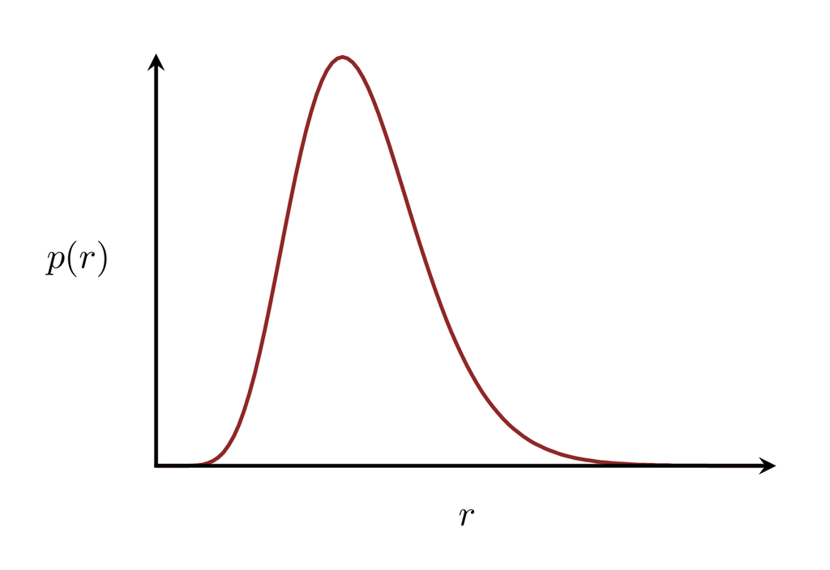

(a)

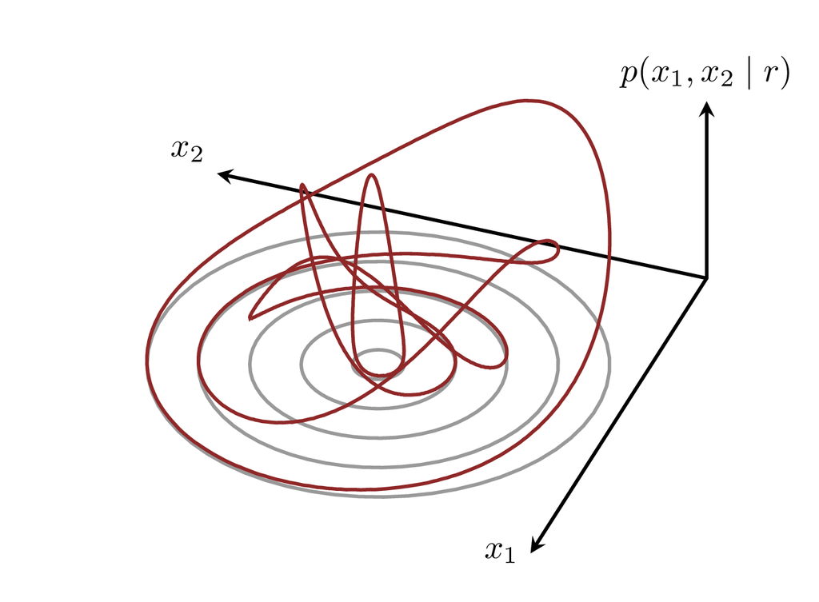

(b)

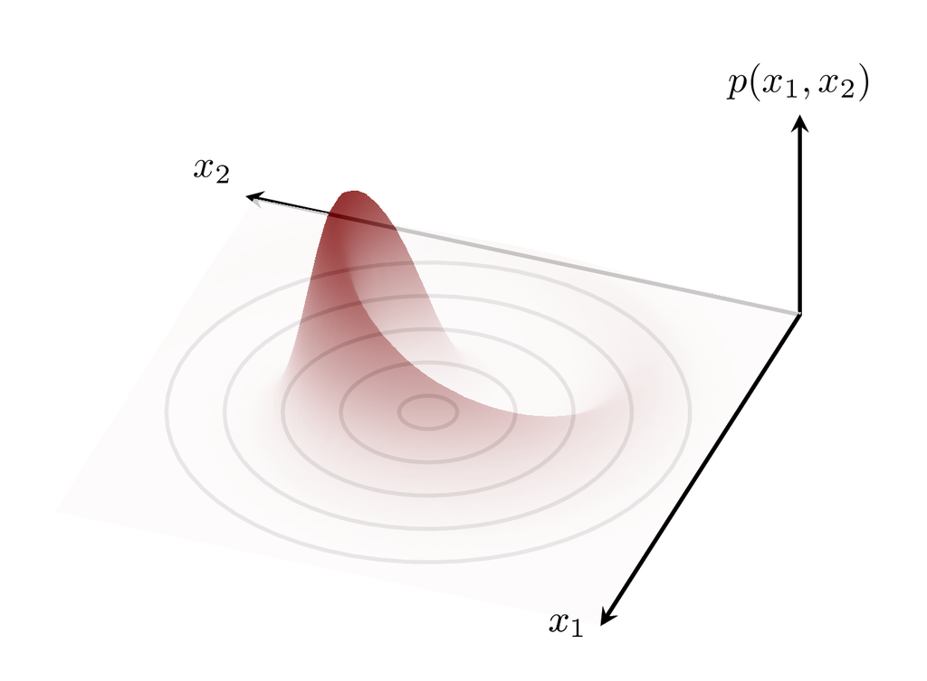

(c)

Figure 7: Conditional probability theory can be used to construct sophisticated probability density functions from simpler pieces. Given a function $f: X \rightarrow Y$ and appropriate reference measures, any (a) output probability density function over $Y$ and (b) conditional probability density functions over the level sets $f^{-1}(y)$ define (c) a probability density function over $X$.

# 8 Conditional Independence

In [Chapter 8, Section 4](http://www.symplectomorphic.com/assets/chapters_html/conditional_probability_theory.html#sec:independence), we discussed various notions of conditional independence. The most relevant being when the conditional probability distributions in a conditional probability kernel behave the same across almost all level sets.

Conditional independence imposes strong structural constraints on conditional probability density functions. In particular, any conditional probability density functions defined relative to the disintegration of an ambient reference measure must be the same for all values of the output variable $y$. In this case, the product rule becomes
$$\frac{ \mathrm{d} \pi }{ \mathrm{d} \mu } (y, x_{y})
\overset{\mu}{=}
\frac{ \mathrm{d} \pi^{f} }{ \mathrm{d} \mu^{f, \nu} } (x_{y}) \,
\frac{ \mathrm{d} f_{*} \pi }{ \mathrm{d} \nu } (y),$$
or, using less explicit but more compact notation,
$$p(x) = p( x_{y} ) \, p(y).$$
Regardless of which level set $f^{-1}(y)$ we choose, the conditional behavior is the same.

This result suggests a straightforward procedure for constructing probability distributions that are conditional independent with respect to a function $f : X \rightarrow Y$. Any function $p : Y \rightarrow \mathbb{R}^{+}$ with $\mathbb{I}_{\nu} \! \left[ r \right] = 1$ implicitly defines an output probability distribution over $Y$. If the level sets $f^{-1}(y)$ are almost all equivalent to some common space $L$, then any function $l : L \rightarrow \mathbb{R}^{+}$ with $\mathbb{I}_{\mu^{f, \nu}} \! \left[ l \right] = 1$ implicitly defines a probability distribution over the common level set space. The product of these two functions,
$$p(x) = l( x_{f(x)} ) \cdot p( f(x) ),$$
defines a probability distribution over $X$ that is conditionally independent of $f$.

Consider, for instance, the example from Section 7.3 only with conditional probability density functions that are independent of $r$,
$$\begin{align*}
p( \theta_{r} \mid r )
&=
\frac{1}{2 \, \pi \, I_{0}(\kappa) }
\exp( \, \kappa \, \cos( \theta_{r} - \pi / 3) \, )
\\
&\equiv
p( \theta_{r} ).
\end{align*}$$

The resulting probability density function still varies with radius and angle, but the dependencies are independent of each other (Figure 8),
$$p( x_{1}, x_{2} )
=
p( \mathrm{atan2}(x_{2}, x_{1}) ) \,
p( f(x_{1}, x_{2}) ).$$

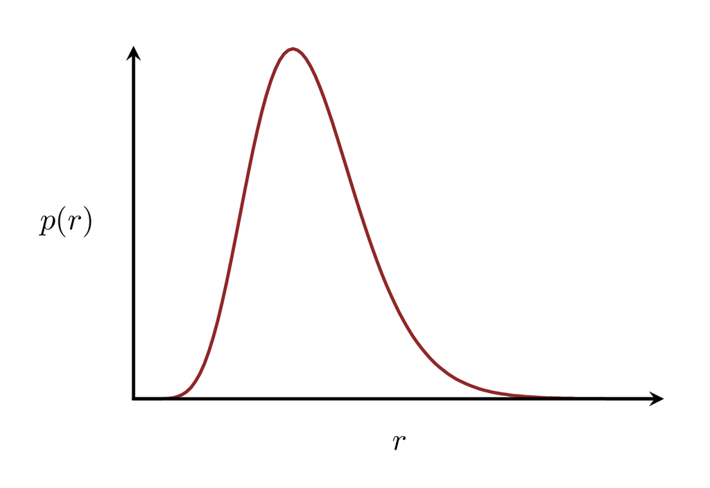

(a)

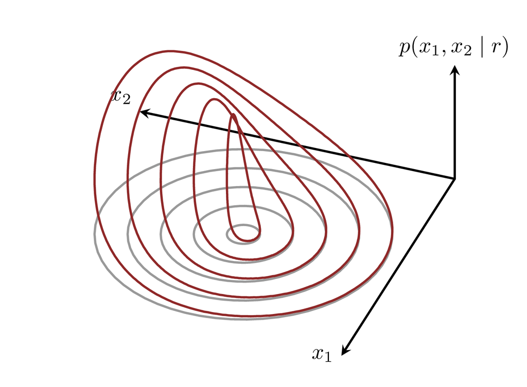

(b)

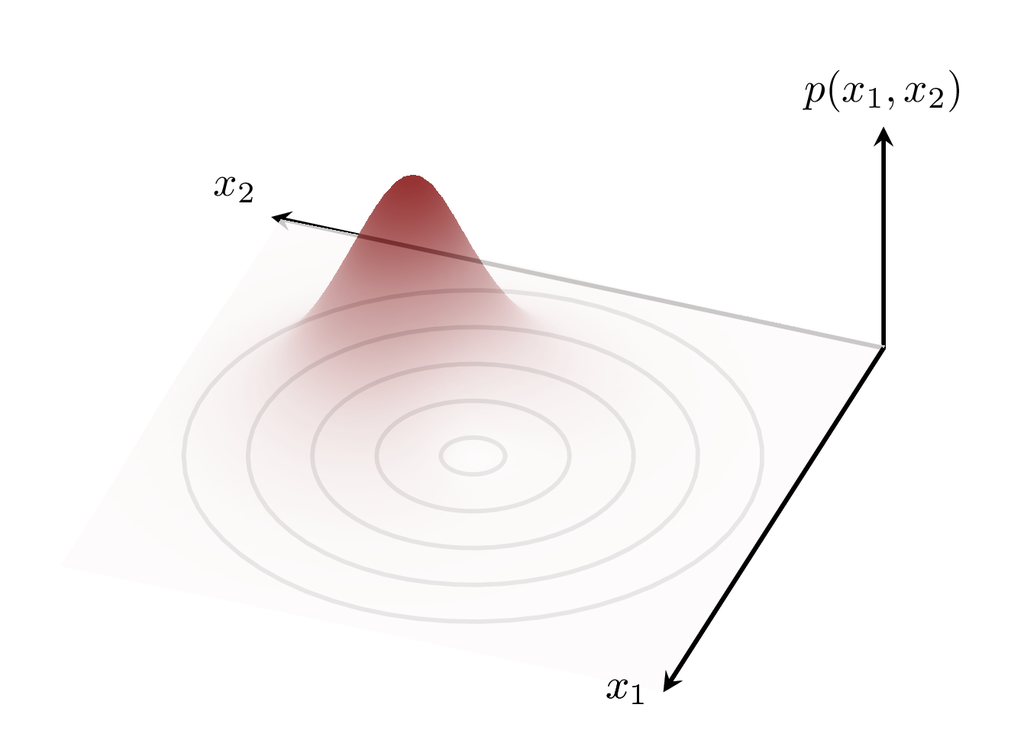

(c)

Figure 8: (b) By using the same conditional probability density function for almost all level sets $f^{-1}(y)$, (c) the derived probability distribution over $X$ is conditionally independent of the function $f$. The only radial dependence comes from (a) the output probability distribution.

# 9 Conclusion

Ultimately, the properties of conditional probability density functions are relatively straightforward, despite the technical minefield we had to navigate to derive them.

Provided that we use consistent reference measures, we can condition an initial probability density function with respect to a function by computing the pushforward probability density function and dividing. At the same time, multiplying an output probability density function and a conditional density function defines a probability density function over the ambient space.

Aside from the general difficulty of conditional integration, the main frustration with conditional probability density functions is one of notation. If we make the conditioning function and its level sets explicit, then the equations can become dense and awkward to parse. On the other hand, if we hide these details, then the equations can be prone to misinterpretation.

Fortunately, much of this frustration is ameliorated when we apply conditional probability theory to *product spaces* and their natural projection functions. We’ll explore this application in detail in [Chapter 10](http://www.symplectomorphic.com/assets/chapters_html/probability_theory_on_product_spaces.html).

# Appendix: “Explicit” Calculations

In this appendix, I’ve sequestered the nasty integrals that arise when deriving the pushforward probability density function, and the subsequent conditional probability density functions, shown in Figure 6. This section is completely optional!

We begin with a two-dimensional, non-negative real space $X = \mathbb{R}^{+} \times \mathbb{R}^{+}$, equipped with a Lebesgue reference measure and the Lebesgue probability density function
$$\begin{align*}
p(x_{1}, x_{2})
&=
\frac{
\exp \left( - \frac{1}{2 \, s^{2}} \frac{1}{1 - \rho^{2}}
( x^{2} - 2 \, \rho \, x \, y + y^{2} ) \right)
}{
\int_{0}^{\infty} \int_{0}^{\infty}
\mathrm{d} x_{1} \, \mathrm{d} x_{2} \,
\exp \left( - \frac{1}{2 \, s^{2}} \frac{1}{1 - \rho^{2}}
( x^{2} - 2 \, \rho \, x \, y + y^{2} ) \right).
}
\\
&=
C \,
\exp \left(
- \frac{1}{2 \, s^{2}} \frac{1}{1 - \rho^{2}}
( x^{2} - 2 \, \rho \, x \, y + y^{2} )
\right),
\end{align*}$$

Our goal will be to condition this probability density function with respect to the surjective radial function
$$\begin{alignat*}{6}
f :\; &X& &\rightarrow& \; &\mathbb{R}^{+}&
\\
&(x_{1}, x_{2})& &\mapsto& &r = \sqrt{ x_{1}^{2} + x_{2}^{2} }&.
\end{alignat*}$$

The level sets of $f$ are given by angular arcs of constant radius which we can cover with the curves
$$\begin{alignat*}{6}
\gamma_{r} :\; &[0, \pi / 2 )& &\rightarrow& \; &X&
\\
&\theta& &\mapsto& &( r \, \cos \theta, r \, \sin \theta )&.
\end{alignat*}$$

As we saw in Section 6, evaluating the pushforward probability density function at any output $r$ requires computing the line integral
$$\begin{align*}
p(r)
&=
\int_{0}^{ \frac{\pi}{2} } \mathrm{d} \theta \,
J_{r}(\theta) \, p( \gamma_{r}(\theta) )
\\
&=
\int_{0}^{ \frac{\pi}{2} } \mathrm{d} \theta \,
r \, p( r \, \cos \theta, r \, \sin \theta ).
\end{align*}$$

Now the initial probability density function written in terms of the output radius and level set angular position simplifies to
$$\begin{align*}
p( r \, &\cos \theta, r \, \sin \theta )
\\
&=
C \, \exp \left(
- \frac{1}{2 \, s^{2}} \frac{1}{1 - \rho^{2}}
(
(r \, \cos \theta)^{2}
- 2 \, \rho \, r \, \cos \theta \, r \, \sin \theta
+ (r \, \sin \theta)^{2}
)
\right)
\\
&=
C \, \exp \left(
- \frac{1}{2 \, s^{2}} \frac{1}{1 - \rho^{2}}
( r^{2} \, \cos^{2} \theta
- 2 \, \rho \, r^{2} \, \cos \theta \, \sin \theta
+ r^{2} \, \sin^{2} \theta )
\right)
\\
&=
C \, \exp \left(
- \frac{1}{2 \, s^{2}} \frac{r^{2}}{1 - \rho^{2}}
( \sin^{2} \theta
+ \cos^{2} \theta
- 2 \, \rho \, \sin \theta \, \cos \theta )
\right)
\\
&=
C \, \exp \left(
- \frac{1}{2 \, s^{2}} \frac{r^{2}}{1 - \rho^{2}}
( 1 - 2 \, \rho \, \sin \theta \, \cos \theta )
\right)
\\
&=
C \, \exp \left(
- \frac{1}{2 \, s^{2}} \frac{r^{2}}{1 - \rho^{2}}
( 1 - \rho \, \sin 2 \theta)
\right).
\end{align*}$$

Consequently,
$$\begin{align*}
p(r)
&=
\int_{0}^{\frac{\pi}{2}} \mathrm{d} \theta \, r \,
p( r \, \cos \theta, r \, \sin \theta )
\\
&=
\int_{0}^{\frac{\pi}{2}} \mathrm{d} \theta \,
C \, r \, \exp \left( - \frac{1}{2 \, s^{2}} \frac{r^{2}}{1 - \rho^{2}}
( 1 - \rho \, \sin 2 \theta)
\right)
\\
&=
C \, r \,
\int_{0}^{\frac{\pi}{2}} \mathrm{d} \theta \,
\exp \left( - \frac{1}{2 \, s^{2}} \frac{r^{2}}{1 - \rho^{2}}
\right) \,
\exp \left( + \frac{1}{2 \, s^{2}} \frac{r^{2}}{1 - \rho^{2}} \,
\rho \, \sin 2 \theta
\right)
\\
&=
C \, r \,
\exp \left(
- \frac{1}{2 \, s^{2}} \frac{r^{2}}{1 - \rho^{2}}
\right) \,
\int_{0}^{\frac{\pi}{2}} \mathrm{d} \theta \,
\exp \left(
+ \frac{r^{2}}{2 \, s^{2}} \frac{\rho}{1 - \rho^{2}} \,
\sin 2 \theta
\right)
\\
&\equiv
C \, r \,
\exp \left(
- \frac{1}{2 \, s^{2}} \frac{r^{2}}{1 - \rho^{2}}
\right) \,
i(r, \rho, \theta).
\end{align*}$$

Conveniently, this integral can be reduced to special functions, albeit not necessarily common ones,
$$\begin{align*}
i(r, \rho, \theta)
&=
\int_{0}^{\frac{\pi}{2}} \mathrm{d} \theta \,
\exp \left(
+ \frac{r^{2}}{2 \, s^{2}} \frac{\rho}{1 - \rho^{2}} \,
\sin 2 \theta
\right)
\\
&=
\frac{1}{2} \int_{0}^{\pi} \mathrm{d} \phi \,
\exp \left(
+ \frac{r^{2}}{2 \, s^{2}} \frac{\rho}{1 - \rho^{2}} \,
\sin \phi
\right)
\\
&=
\frac{\pi}{2} \left(
I_{0} \left(
\frac{r^{2}}{2 \, s^{2}} \frac{\rho}{1 - \rho^{2}}
\right)
+ L_{0} \left(
\frac{r^{2}}{2 \, s^{2}} \frac{\rho}{1 - \rho^{2}}
\right)
\right),
\end{align*}$$
where $I_{0}(x)$ is the **zeroth-order modified Bessel function of the first kind** and $L_{0}(x)$ is the **zeroth-order modified Struve function** (Abramowitz and Stegun 1964).

Using this result, the pushforward probability density function becomes
$$\begin{align*}
p(r)
&=
C \, r \,
\exp \left(
- \frac{1}{2 \, s^{2}} \frac{r^{2}}{1 - \rho^{2}}
\right) \,
\iota(r, \rho, \theta)
\\
&=
\frac{\pi}{2} \, C \, r \,
\exp \left(
- \frac{1}{2 \, s^{2}} \frac{r^{2}}{1 - \rho^{2}}
\right) \,
\left(
I_{0} \left(
\frac{r^{2}}{2 \, s^{2}} \frac{\rho}{1 - \rho^{2}}
\right)
+ L_{0} \left(
\frac{r^{2}}{2 \, s^{2}} \frac{\rho}{1 - \rho^{2}}
\right)
\right).
\end{align*}$$

Once we have calculated the pushfoward probability density function in closed form, the conditional probability density function immediately follows,
$$\begin{align*}
p(\theta \mid r)
&=
\frac{ p(r, \theta) }{ p(r) }
\\
&=
\frac{
C \, r \, \exp \left(
- \frac{1}{2 \, s^{2}} \frac{r^{2}}{1 - \rho^{2}}
( 1 - \rho \, \sin 2 \theta)
\right)
}{
\frac{\pi}{2} \, C \, r \,
\exp \left(
- \frac{1}{2 \, s^{2}} \frac{r^{2}}{1 - \rho^{2}}
\right) \,
\left(
I_{0} \left(
\frac{r^{2}}{2 \, s^{2}} \frac{\rho}{1 - \rho^{2}}
\right)
+ L_{0} \left(
\frac{r^{2}}{2 \, s^{2}} \frac{\rho}{1 - \rho^{2}}
\right)
\right)
}
\\
&=
\frac{
\exp \left(
- \frac{1}{2 \, s^{2}} \frac{r^{2}}{1 - \rho^{2}}
( 1 - \rho \, \sin 2 \theta)
\right)
}{
\frac{\pi}{2} \,
\exp \left(
- \frac{1}{2 \, s^{2}} \frac{r^{2}}{1 - \rho^{2}}
\right) \,
\left(
I_{0} \left(
\frac{r^{2}}{2 \, s^{2}} \frac{\rho}{1 - \rho^{2}}
\right)
+ L_{0} \left(
\frac{r^{2}}{2 \, s^{2}} \frac{\rho}{1 - \rho^{2}}
\right)
\right)
}
\\
&=
\frac{2}{\pi} \,
\frac{
\exp \left(
- \frac{1}{2 \, s^{2}} \frac{r^{2}}{1 - \rho^{2}}
( 1 - \rho \, \sin 2 \theta)
+ \frac{1}{2 \, s^{2}} \frac{r^{2}}{1 - \rho^{2}}
\right)
}{
I_{0} \left(
\frac{r^{2}}{2 \, s^{2}} \frac{\rho}{1 - \rho^{2}}
\right)
+ L_{0} \left(
\frac{r^{2}}{2 \, s^{2}} \frac{\rho}{1 - \rho^{2}}
\right)
}
\\
&=
\frac{2}{\pi} \,
\frac{
\exp \left(
- \frac{1}{2 \, s^{2}} \frac{r^{2}}{1 - \rho^{2}}
(- \rho \, \sin 2 \theta)
\right)
}{
I_{0} \left(
\frac{r^{2}}{2 \, s^{2}} \frac{\rho}{1 - \rho^{2}}
\right)
+ L_{0} \left(
\frac{r^{2}}{2 \, s^{2}} \frac{\rho}{1 - \rho^{2}}
\right)
}
\\
&=
\frac{2}{\pi} \,
\frac{
\exp \left(+ \alpha(r) \, \sin 2 \theta \right)
}{
I_{0} \left( \alpha(r) \right) + L_{0} \left( \alpha(r) \right)
},
\end{align*}$$
where
$$\alpha(r) = \frac{r^{2}}{2 \, s^{2}} \frac{\rho}{1 - \rho^{2}}.$$

By construction, each individual conditional probability density function is guaranteed to be properly normalized,
$$\begin{align*}
\int_{0}^{\frac{\pi}{2}} \mathrm{d} \theta \, p(\theta \mid r)
&=
\int_{0}^{\frac{\pi}{2}} \mathrm{d} \theta \,
\frac{2}{\pi} \,
\frac{
\exp \left( + \alpha(r) \, \sin 2 \theta \right)
}{
I_{0} \left( \alpha(r) \right) + L_{0} \left( \alpha(r) \right)
}
\\
&=
\frac{2}{\pi} \,
\frac{1}{
I_{0} \left( \alpha(r) \right) + L_{0} \left( \alpha(r) \right)
}
\int_{0}^{\frac{\pi}{2}} \mathrm{d} \theta \,
\exp \left( + \alpha(r) \, \sin 2 \theta \right)
\\
&=
\frac{1}{\pi} \,
\frac{1}{
I_{0} \left( \alpha(r) \right) + L_{0} \left( \alpha(r) \right)
}
\int_{0}^{\pi} \mathrm{d} \phi \,
\exp \left( + \alpha(r) \, \sin \phi \right)
\\
&=
\frac{1}{\pi} \,
\frac{1}{
I_{0} \left( \alpha(r) \right) + L_{0} \left( \alpha(r) \right)
}
\pi \left(
I_{0} \left( \alpha(r) \right) + L_{0} \left( \alpha(r) \right)
\right)
\\
&=
\frac{\pi}{\pi} \,
\frac{
I_{0} \left( \alpha(r) \right) + L_{0} \left( \alpha(r) \right)
}{
I_{0} \left( \alpha(r) \right) + L_{0} \left( \alpha(r) \right)
}
\\
&=
1.
\end{align*}$$

# Acknowledgements

A very special thanks to everyone supporting me on Patreon: Adam Fleischhacker, Adriano Yoshino, Alessandro Varacca, Alexander Noll, Alexander Petrov, Alexander Rosteck, Andrea Serafino, Andrew Mascioli, Andrew Rouillard, Andrew Vigotsky, Ara Winter, Austin Rochford, Avraham Adler, Ben Matthews, Ben Swallow, Benoit Essiambre, Bradley Kolb, Brandon Liu, Brendan Galdo, Brynjolfur Gauti Jónsson, Cameron Smith, Canaan Breiss, Cat Shark, Charles Naylor, Charles Shaw, Chase Dwelle, Chris Jones, Christopher Mehrvarzi, Colin Carroll, Colin McAuliffe, Damien Mannion, dan mackinlay, Dan W Joyce, Dan Waxman, Dan Weitzenfeld, Daniel Edward Marthaler, Darshan Pandit, Darthmaluus, David Galley, David Wurtz, Denis Vlašiček, Doug Rivers, Dr. Jobo, Dr. Omri Har Shemesh, Dylan Maher, Ed Cashin, Edgar Merkle, Eric LaMotte, Ero Carrera, Eugene O’Friel, Felipe González, Fergus Chadwick, Finn Lindgren, Florian Wellmann, Geoff Rollins, Guido Biele, Håkan Johansson, Hamed Bastan-Hagh, Haonan Zhu, Hector Munoz, Henri Wallen, hs, Hugo Botha, Ian, Ian Costley, idontgetoutmuch, Ignacio Vera, Ilaria Prosdocimi, Isaac Vock, J, J Michael Burgess, jacob pine, Jair Andrade, James C, James Hodgson, James Wade, Janek Berger, Jason Martin, Jason Pekos, Jason Wong, Jeff Burnett, Jeff Dotson, Jeff Helzner, Jeffrey Erlich, Jesse Wolfhagen, Jessica Graves, Joe Wagner, John Flournoy, Jonathan H. Morgan, Jonathon Vallejo, Joran Jongerling, JU, Justin Bois, Kádár András, Karim Naguib, Karim Osman, Kejia Shi, Kristian Gårdhus Wichmann, Lars Barquist, lizzie , LOU ODETTE, Luís F, Marcel Lüthi, Marek Kwiatkowski, Mark Donoghoe, Markus P., Martin Modrák, Márton Vaitkus, Matt Moores, Matthew, Matthew Kay, Matthieu LEROY, Mattia Arsendi, Maurits van der Meer, Michael Colaresi, Michael DeWitt, Michael Dillon, Michael Lerner, Mick Cooney, N Sanders, N.S. , Name, Nathaniel Burbank, Nic Fishman, Nicholas Clark, Nicholas Cowie, Nick S, Octavio Medina, Oliver Crook, Olivier Ma, Patrick Kelley, Patrick Boehnke, Pau Pereira Batlle, Peter Johnson, Pieter van den Berg, ptr, Ramiro Barrantes Reynolds, Raúl Peralta Lozada, Ravin Kumar, Rémi, Riccardo Fusaroli, Richard Nerland, Robert Frost, Robert Goldman, Robert kohn, Robin Taylor, Ryan Grossman, S Hong, Saleem Huda, Sean Wilson, Sergiy Protsiv, Seth Axen, shira, Simon Duane, Simon Lilburn, sssz, Stan_user, Stephen Lienhard, Stew Watts, Stone Chen, Susan Holmes, Svilup, Tao Ye, Tate Tunstall, Tatsuo Okubo, Teresa Ortiz, Theodore Dasher, Thomas Kealy, Thomas Vladeck, Tiago Cabaço, Tim Radtke, Tobychev , Tom McEwen, Tomáš Frýda, Tony Wuersch, Virginia Fisher, Vladimir Markov, Wil Yegelwel, Will Farr, woejozney, yolhaj , yureq , Zach A, Zad Rafi, and Zhengchen Cai.

# References

Abramowitz, Milton, and Irene A. Stegun. 1964. *Handbook of Mathematical Functions with Formulas, Graphs, and Mathematical Tables*. National Bureau of Standards Applied Mathematics Series, No. 55. U. S. Government Printing Office, Washington, DC.

Apostol, Tom M. 1969. *Calculus. Vol. II: Multi-Variable Calculus and Linear Algebra, with Applications to Differential Equations and Probability*. Second. Blaisdell Publishing Co. [Ginn; Co.], Waltham, Mass.-Toronto, Ont.-London.

Chang, Joseph T, and David Pollard. 1997. “Conditioning as Disintegration.” *Statistica Neerlandica* 51 (3): 287–317.

Larson, R., R. P. Hostetler, and B. H. Edwards. 1990. *Calculus with Analytic Geometry*. Fourth. Lexington, Massachusetts: D.C. Heath; Company.

# License

The text and figures in this chapter are copyrighted by Michael Betancourt and licensed under the [CC BY-NC 4.0 license](https://creativecommons.org/licenses/by-nc/4.0/).